# Grand Cross-Study Plant Allometry: Theory Testing, Inter- and Intraspecific Scaling

OLS, SMA/RMA, PGLS across Tallo, BAAD, NEON, ForestGEO Panama, Shenkin 2020 Andean Crown Dimensions, Niklas-Enquist

plant_scaling_data project

2026-05-06

# 1 Data Loading and Harmonisation

```r
tallo_raw <- read_csv(file.path(proj_dir, "data/raw/tallo/Tallo.csv"),
                      show_col_types = FALSE)
tallo_clean <- tallo_raw |>
  filter(height_outlier != "Y" | is.na(height_outlier),
         crown_radius_outlier != "Y" | is.na(crown_radius_outlier),
         !grepl("^sp\\.?$", species, ignore.case = TRUE),
         !is.na(stem_diameter_cm), stem_diameter_cm > 0) |>
  mutate(
    source        = "Tallo",
    DBH_cm        = stem_diameter_cm,
    Height_m      = height_m,
    AGB_kg        = NA_real_,
    AGB_method    = NA_character_,
    CrownRadius_m = crown_radius_m,
    genus         = genus,
    family        = family,
    division      = division,
    lat           = latitude,
    lon           = longitude,
    agb_eligible  = FALSE
  ) |>
  select(source, DBH_cm, Height_m, AGB_kg, AGB_method, CrownRadius_m,
         species, genus, family, division, lat, lon, agb_eligible)
```

```r
if (HAS_BAAD) {
  baad_raw <- baad.data::baad_data()$data
  baad_clean <- baad_raw |>
    mutate(
      source        = "BAAD",
      DBH_cm        = d.bh * 100,   # CRITICAL: d.bh is in metres
      Height_m      = h.t,
      AGB_kg        = m.to,
      AGB_method    = "direct",
      CrownRadius_m = NA_real_,
      species       = speciesMatched,
      genus         = word(speciesMatched, 1),
      family        = NA_character_,
      division      = NA_character_,
      lat           = NA_real_,
      lon           = NA_real_,
      agb_eligible  = !is.na(m.to)
    ) |>
    filter(!is.na(DBH_cm), DBH_cm > 0) |>
    select(source, DBH_cm, Height_m, AGB_kg, AGB_method, CrownRadius_m,
           species, genus, family, division, lat, lon, agb_eligible)
} else {
  baad_raw   <- NULL
  baad_clean <- tibble(source = character(), DBH_cm = numeric(),
    Height_m = numeric(), AGB_kg = numeric(), AGB_method = character(),
    CrownRadius_m = numeric(), species = character(), genus = character(),
    family = character(), division = character(), lat = numeric(),
    lon = numeric(), agb_eligible = logical())
  message("baad.data not available — BAAD sections will be skipped.")
}
```

```r
neon_sites <- c("BART","BLAN","CLBJ","DELA","DSNY","GRSM","GUAN","HARV",
                "JERC","KONZ","LENO","MLBS","ORNL","OSBS","RMNP","SCBI",
                "SERC","STEI","TALL","TREE","UKFS","UNDE","YELL")
bm_dir <- file.path(proj_dir, "data/raw/neon_forest_agb/biomass")

site_coords <- tryCatch(
  read_csv(file.path(proj_dir, "data/raw/neon_forest_agb/sitecoordinates.csv"),
           show_col_types = FALSE),
  error = function(e) tibble(siteID = character(), X = numeric(), Y = numeric()))

neon_list <- map(neon_sites, function(s) {
  tryCatch({
    d <- read_csv(file.path(bm_dir, paste0(s, "_biomass.csv")),
                  show_col_types = FALSE)
    d |>
      filter(plantStatus == "Live" | is.na(plantStatus),
             !is.na(stemDiameter), stemDiameter > 0) |>
      mutate(
        source        = "NEON",
        siteID_tmp    = s,
        DBH_cm        = stemDiameter,
        Height_m      = height,
        AGB_kg        = AGBChojnacky,
        AGB_method    = "allometric_chojnacky",
        CrownRadius_m = NA_real_,
        species       = scientificName,
        genus         = Genus,
        family        = Family,
        division      = NA_character_,
        agb_eligible  = FALSE
      ) |>
      left_join(site_coords |> select(siteID, lon = X, lat = Y),
                by = c("siteID_tmp" = "siteID")) |>
      select(source, DBH_cm, Height_m, AGB_kg, AGB_method, CrownRadius_m,
             species, genus, family, division, lat, lon, agb_eligible)
  }, error = function(e) NULL)
})
neon_clean <- bind_rows(Filter(Negate(is.null), neon_list))
```

```r
fgeo_raw <- read_csv(
  file.path(proj_dir,
    "data/raw/forestgeo_panama/TreeHeightDataSmallPlotsCombined_2024_08_05.csv"),
  show_col_types = FALSE)

# BCI / Panama small-plot approximate centroid
FGEO_LAT <- 9.15; FGEO_LON <- -79.84

fgeo_clean <- fgeo_raw |>
  filter(!is.na(DBH_mm), DBH_mm > 0, !is.na(TreeHt_m), TreeHt_m > 0) |>
  mutate(
    source        = "ForestGEO_Panama",
    DBH_cm        = DBH_mm / 10,
    Height_m      = TreeHt_m,
    AGB_kg        = NA_real_,
    AGB_method    = NA_character_,
    CrownRadius_m = NA_real_,
    species       = LatinBinomial,
    genus         = word(LatinBinomial, 1),
    family        = NA_character_,
    division      = NA_character_,
    lat           = FGEO_LAT,
    lon           = FGEO_LON,
    agb_eligible  = FALSE
  ) |>
  select(source, DBH_cm, Height_m, AGB_kg, AGB_method, CrownRadius_m,
         species, genus, family, division, lat, lon, agb_eligible)
```

```r
nik_col_names <- c(
  "taxa","citation","footnotes","record_num","age_yr","log_age",
  "height_m","log_height","root_biomass_kg","log_root","stem_biomass_kg",
  "log_stem","leaf_biomass_kg","log_leaf","shoot_biomass_kg","log_shoot",
  "repro_biomass_kg","log_repro","total_biomass_kg","log_total",
  "stem_growth_kgyr","log_stem_growth","leaf_growth_kgyr","log_leaf_growth",
  "root_growth_kgyr","log_root_growth","total_growth_kgyr","log_total_growth")

nik_enq <- read_csv(
  file.path(proj_dir, "data/raw/niklas_enquist/niklas_enquist_biomass_20040122.csv"),
  skip = 2, col_names = nik_col_names,
  locale = locale(encoding = "latin1"), show_col_types = FALSE) |>
  mutate(across(-c(taxa, citation, footnotes), as.numeric)) |>
  mutate(across(where(is.numeric), ~ ifelse(. == -999, NA_real_, .))) |>
  mutate(pgls_eligible = !grepl(
    "with a few|community|stand|plot|mixed", taxa, ignore.case = TRUE))
```

```r
shenkin_raw <- read_csv(
  file.path(proj_dir, "data/raw/shenkin/shenkin_etal_2020_crown_dimensions.csv"),
  show_col_types = FALSE)

shenkin_clean <- shenkin_raw |>
  filter(!is.na(DBH), DBH > 0) |>
  mutate(
    source        = "Shenkin_2020",
    DBH_cm        = DBH,                             # column already in cm
    Height_m      = `tree_height (m)`,
    AGB_kg        = NA_real_,
    AGB_method    = NA_character_,
    CrownRadius_m = `crown_radius  (m)`,
    species       = species,
    genus         = word(species, 1),
    family        = family,
    division      = NA_character_,
    lat           = lat,
    lon           = lon,
    agb_eligible  = FALSE
  ) |>
  select(source, DBH_cm, Height_m, AGB_kg, AGB_method, CrownRadius_m,
         species, genus, family, division, lat, lon, agb_eligible)
```

```r
allom <- bind_rows(tallo_clean, baad_clean, neon_clean, fgeo_clean, shenkin_clean) |>
  filter(!is.na(species), species != "",
         !grepl("^sp\\.?$|^[A-Z][a-z]+ sp\\.$", species, ignore.case = FALSE))
```

```r
src_summary <- allom |>
  group_by(source) |>
  summarise(
    N_records = n(),
    N_species = n_distinct(species, na.rm = TRUE),
    N_families = n_distinct(family[!is.na(family)]),
    lat_range = ifelse(all(is.na(lat)), "NA",
      paste0(round(min(lat, na.rm = TRUE), 1), " to ",
             round(max(lat, na.rm = TRUE), 1))),
    lon_range = ifelse(all(is.na(lon)), "NA",
      paste0(round(min(lon, na.rm = TRUE), 1), " to ",
             round(max(lon, na.rm = TRUE), 1))),
    .groups = "drop")

kable(src_summary, caption = "Summary of harmonised allom tibble by source.",
      format.args = list(big.mark = ","))
```

Summary of harmonised allom tibble by source.

| source | N_records | N_species | N_families | lat_range | lon_range |
| --- | --- | --- | --- | --- | --- |
| BAAD | 8,506 | 369 | 0 | NA | NA |
| ForestGEO_Panama | 5,107 | 353 | 0 | 9.2 to 9.2 | -79.8 to -79.8 |
| NEON | 101,708 | 297 | 72 | 18 to 46.2 | -110.5 to -66.9 |
| Shenkin_2020 | 1,153 | 278 | 96 | -14.8 to 7.3 | -71.6 to -1.2 |
| Tallo | 436,805 | 5,156 | 187 | -51.6 to 69.9 | -155.3 to 177 |

# 2 Geographic Overview

```r
# Subsample Tallo for leaflet performance
set.seed(42)
tallo_ll <- tallo_clean |>
  filter(!is.na(lat), !is.na(lon)) |>
  sample_n(min(20000, n())) |>
  mutate(col = "#2196F3")

neon_ll <- site_coords |>
  filter(!is.na(X), !is.na(Y)) |>
  mutate(source = "NEON", lat = Y, lon = X, col = "#FF5722")

fgeo_ll <- data.frame(lat = FGEO_LAT, lon = FGEO_LON,
                      source = "ForestGEO_Panama", col = "#4CAF50")

# Shenkin 2020 Andean plots — one point per unique plot centroid
shenkin_ll <- shenkin_raw |>
  filter(!is.na(lat), !is.na(lon)) |>
  distinct(plot, .keep_all = TRUE) |>
  mutate(source = "Shenkin_2020", col = "#E91E63",
         popup_txt = paste0(plot, "<br>Region: ", region,
                            "<br>Elevation: ", `ele_asl (m)`, " m"))

pal_src <- colorFactor(
  palette = c("#2196F3","#9C27B0","#FF5722","#4CAF50","#E91E63"),
  levels  = c("Tallo","BAAD","NEON","ForestGEO_Panama","Shenkin_2020"))

m <- leaflet() |>
  addTiles() |>
  addCircleMarkers(data = tallo_ll, ~lon, ~lat, radius = 2,
    color = "#2196F3", opacity = 0.4, fillOpacity = 0.4,
    group = "Tallo") |>
  addCircleMarkers(data = neon_ll, ~lon, ~lat, radius = 7,
    color = "#FF5722", opacity = 0.9, fillOpacity = 0.9,
    popup = ~siteID, group = "NEON sites") |>
  addCircleMarkers(data = fgeo_ll, ~lon, ~lat, radius = 8,
    color = "#4CAF50", opacity = 0.9, fillOpacity = 0.9,
    popup = "ForestGEO Panama", group = "ForestGEO Panama") |>
  addCircleMarkers(data = shenkin_ll, ~lon, ~lat, radius = 8,
    color = "#E91E63", opacity = 0.9, fillOpacity = 0.9,
    popup = ~popup_txt, group = "Shenkin 2020 (Andes)") |>
  addLayersControl(overlayGroups = c("Tallo","NEON sites","ForestGEO Panama",
                                     "Shenkin 2020 (Andes)"),
                   options = layersControlOptions(collapsed = FALSE))
m
```

[interactive chart not shown]

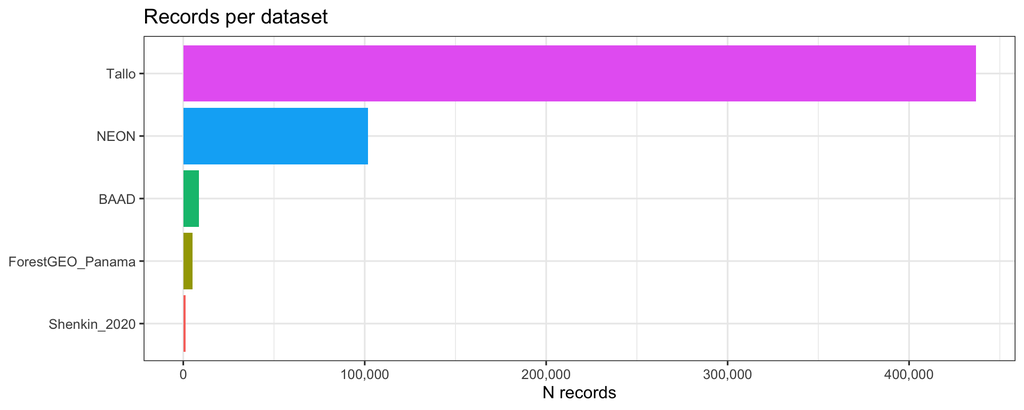

```r
allom |>
  count(source) |>
  mutate(source = reorder(source, n)) |>
  ggplot(aes(source, n, fill = source)) +
  geom_col(show.legend = FALSE) +
  scale_y_continuous(labels = comma) +
  coord_flip() +
  labs(title = "Records per dataset", x = NULL, y = "N records")
```

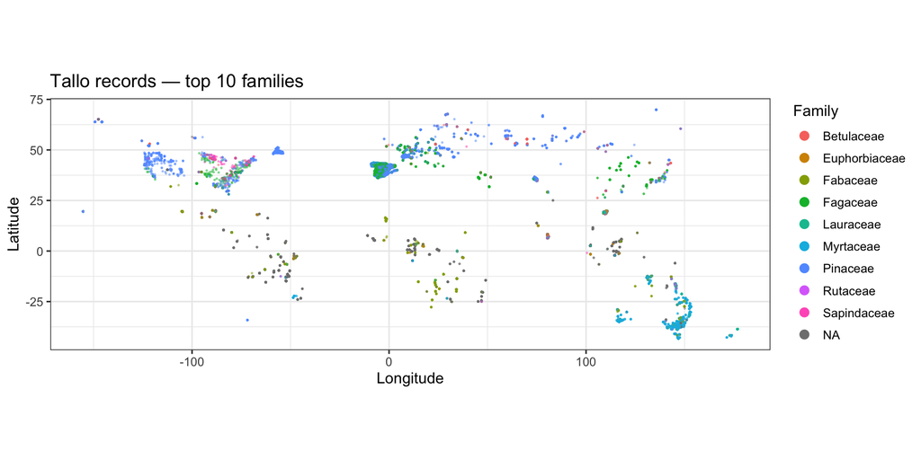

```r
top10_fam <- tallo_clean |>
  count(family, sort = TRUE) |>
  slice(1:10) |>
  pull(family)

set.seed(42)
tallo_clean |>
  filter(!is.na(lat), !is.na(lon), family %in% top10_fam) |>
  sample_n(min(50000, n())) |>
  ggplot(aes(lon, lat, colour = family)) +
  geom_point(size = 0.3, alpha = 0.4) +
  coord_quickmap() +
  labs(title = "Tallo records — top 10 families",
       x = "Longitude", y = "Latitude", colour = "Family") +
  guides(colour = guide_legend(override.aes = list(size = 3, alpha = 1)))
```

# 3 Taxonomic Coverage and Size Range Audit

```r
fam_audit <- allom |>
  filter(!is.na(DBH_cm), DBH_cm > 0, !is.na(family)) |>
  group_by(family, division) |>
  summarise(
    n_records   = n(),
    n_species   = n_distinct(species, na.rm = TRUE),
    n_datasets  = n_distinct(source),
    log10_range = log10(max(DBH_cm, na.rm = TRUE) /
                          max(min(DBH_cm, na.rm = TRUE), 1e-6)),
    .groups = "drop") |>
  mutate(
    pgls_eligible = n_species  >= 8  & log10_range >= 2.0,
    sma_eligible  = (n_species >= 5  | n_records >= 20) & log10_range >= 1.5,
    intra_eligible = n_records >= 10 & log10_range >= 1.5) |>
  arrange(desc(n_records))

kable(head(fam_audit, 30), digits = 2,
      caption = "Family-level coverage and eligibility flags (top 30 by N records).")
```

Family-level coverage and eligibility flags (top 30 by N records).

| family | division | n_records | n_species | n_datasets | log10_range | pgls_eligible | sma_eligible | intra_eligible |
| --- | --- | --- | --- | --- | --- | --- | --- | --- |
| Pinaceae | Gymnosperm | 98089 | 89 | 1 | 2.54 | TRUE | TRUE | TRUE |
| Fagaceae | Angiosperm | 85906 | 151 | 1 | 2.35 | TRUE | TRUE | TRUE |
| Myrtaceae | Angiosperm | 35766 | 369 | 1 | 2.81 | TRUE | TRUE | TRUE |
| Fabaceae | Angiosperm | 22244 | 539 | 1 | 2.40 | TRUE | TRUE | TRUE |
| Pinaceae | NA | 21011 | 26 | 1 | 2.06 | TRUE | TRUE | TRUE |
| Aceraceae | NA | 18326 | 10 | 1 | 1.92 | FALSE | TRUE | TRUE |
| Sapindaceae | Angiosperm | 16165 | 148 | 1 | 2.28 | TRUE | TRUE | TRUE |
| Fagaceae | NA | 13983 | 29 | 1 | 2.43 | TRUE | TRUE | TRUE |
| Lauraceae | Angiosperm | 13943 | 271 | 1 | 2.29 | TRUE | TRUE | TRUE |
| Betulaceae | Angiosperm | 10617 | 41 | 1 | 2.16 | TRUE | TRUE | TRUE |
| Euphorbiaceae | Angiosperm | 8994 | 199 | 1 | 2.07 | TRUE | TRUE | TRUE |
| Rutaceae | Angiosperm | 7922 | 105 | 1 | 2.14 | TRUE | TRUE | TRUE |
| Malvaceae | Angiosperm | 7527 | 175 | 1 | 2.39 | TRUE | TRUE | TRUE |
| Dipterocarpaceae | Angiosperm | 6817 | 105 | 1 | 2.33 | TRUE | TRUE | TRUE |
| Betulaceae | NA | 6137 | 13 | 1 | 1.81 | FALSE | TRUE | TRUE |
| Salicaceae | NA | 5725 | 5 | 1 | 2.23 | FALSE | TRUE | TRUE |
| Rubiaceae | Angiosperm | 5461 | 181 | 1 | 2.17 | TRUE | TRUE | TRUE |
| Ulmaceae | NA | 5348 | 8 | 1 | 2.57 | TRUE | TRUE | TRUE |
| Salicaceae | Angiosperm | 4546 | 69 | 1 | 2.01 | TRUE | TRUE | TRUE |
| Proteaceae | Angiosperm | 4426 | 49 | 1 | 1.88 | FALSE | TRUE | TRUE |
| Oleaceae | Angiosperm | 4401 | 39 | 1 | 2.05 | TRUE | TRUE | TRUE |
| Sapotaceae | Angiosperm | 4387 | 109 | 1 | 2.26 | TRUE | TRUE | TRUE |
| Burseraceae | Angiosperm | 4371 | 68 | 1 | 2.18 | TRUE | TRUE | TRUE |
| Meliaceae | Angiosperm | 3799 | 117 | 1 | 2.45 | TRUE | TRUE | TRUE |
| Elaeocarpaceae | Angiosperm | 3731 | 49 | 1 | 2.19 | TRUE | TRUE | TRUE |
| Cupressaceae | Gymnosperm | 3683 | 25 | 1 | 2.89 | TRUE | TRUE | TRUE |
| Cornaceae | NA | 3653 | 7 | 1 | 1.87 | FALSE | TRUE | TRUE |
| Moraceae | Angiosperm | 3611 | 126 | 1 | 2.36 | TRUE | TRUE | TRUE |
| Hamamelidaceae | NA | 3528 | 2 | 1 | 1.92 | FALSE | TRUE | TRUE |
| Phyllanthaceae | Angiosperm | 3330 | 130 | 1 | 2.05 | TRUE | TRUE | TRUE |

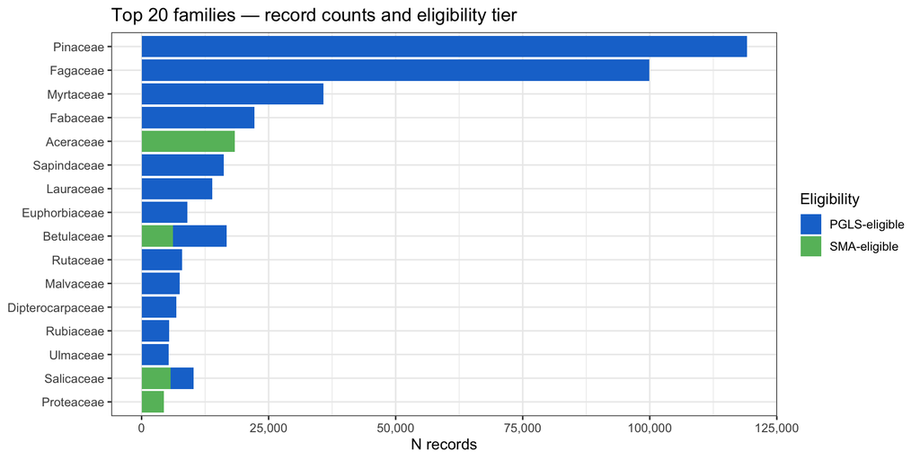

```r
fam_audit |>
  slice(1:20) |>
  mutate(
    tier = case_when(pgls_eligible ~ "PGLS-eligible",
                     sma_eligible  ~ "SMA-eligible",
                     TRUE          ~ "Low coverage"),
    family = reorder(family, n_records)) |>
  ggplot(aes(family, n_records, fill = tier)) +
  geom_col() +
  coord_flip() +
  scale_y_continuous(labels = comma) +
  scale_fill_manual(values = c("PGLS-eligible" = "#1976D2",
                               "SMA-eligible"  = "#66BB6A",
                               "Low coverage"  = "#BDBDBD")) +
  labs(title = "Top 20 families — record counts and eligibility tier",
       x = NULL, y = "N records", fill = "Eligibility")
```

```r
div_sum <- allom |>
  filter(!is.na(division), !is.na(DBH_cm), DBH_cm > 0) |>
  group_by(division) |>
  summarise(n_records = n(), n_species = n_distinct(species),
            DBH_min_cm = min(DBH_cm), DBH_max_cm = max(DBH_cm),
            .groups = "drop")
kable(div_sum, digits = 1, caption = "Division-level summary (DBH records).")
```

Division-level summary (DBH records).

| division | n_records | n_species | DBH_min_cm | DBH_max_cm |
| --- | --- | --- | --- | --- |
| Angiosperm | 334092 | 5010 | 1 | 652 |
| Gymnosperm | 102713 | 146 | 1 | 770 |

# 4 H ~ DBH Scaling

## 4.1 Pooled cross-study

```r
pool_hd <- allom |>
  filter(!is.na(DBH_cm), !is.na(Height_m),
         DBH_cm > 0, Height_m > 0) |>
  mutate(log_dbh = log10(DBH_cm), log_h = log10(Height_m))

ols_hd  <- lm(log_h ~ log_dbh, data = pool_hd)
sma_hd  <- tryCatch(sma(log_h ~ log_dbh, data = pool_hd), error = function(e) NULL)
lmm_hd  <- tryCatch(
  lmer(log_h ~ log_dbh + (1 | source), data = pool_hd, REML = FALSE),
  error = function(e) NULL)

ols_coef <- coef(ols_hd)
sma_coef <- if (!is.null(sma_hd)) as.numeric(coef(sma_hd)[[1]]) else NULL

ols_ci  <- confint(ols_hd, "log_dbh")
sma_ci  <- if (!is.null(sma_hd)) as.numeric(sma_hd$slopetest[[1]]$test[c("lower","upper")]) else c(NA_real_, NA_real_)

sma_test_hd <- if (!is.null(sma_hd)) tryCatch(
  slope.test(pool_hd$log_h, pool_hd$log_dbh, test.value = WBE_H_DBH, method = "SMA"),
  error = function(e) list(p = NA_real_)) else list(p = NA_real_)

lmm_slope <- if (!is.null(lmm_hd)) as.numeric(fixef(lmm_hd)["log_dbh"]) else NA_real_

hd_table <- tibble(
  Method = c("OLS","SMA","LMM (random source)"),
  Slope  = c(as.numeric(ols_coef["log_dbh"]),
             if (!is.null(sma_coef)) as.numeric(sma_coef["slope"]) else NA_real_,
             lmm_slope),
  CI_lo  = c(ols_ci[1], if (!is.null(sma_coef)) sma_ci[1] else NA_real_, NA_real_),
  CI_hi  = c(ols_ci[2], if (!is.null(sma_coef)) sma_ci[2] else NA_real_, NA_real_),
  R2     = c(summary(ols_hd)$r.squared, NA_real_, NA_real_),
  p_vs_WBE = c(
    2 * pt(abs((ols_coef["log_dbh"] - WBE_H_DBH) /
                summary(ols_hd)$coefficients["log_dbh","Std. Error"]),
             df = df.residual(ols_hd), lower.tail = FALSE),
    sma_test_hd$p,
    NA_real_))

kable(hd_table, digits = 3,
      caption = paste0("H ~ DBH pooled regression (N = ", nrow(pool_hd),
                       "). WBE prediction β = 2/3."))
```

H ~ DBH pooled regression (N = 542399). WBE prediction β = 2/3.

| Method | Slope | CI_lo | CI_hi | R2 | p_vs_WBE |
| --- | --- | --- | --- | --- | --- |
| OLS | 0.598 | 0.597 | 0.599 | 0.62 | 0 |
| SMA | NA | NA | NA | NA | 0 |
| LMM (random source) | 0.604 | NA | NA | NA | NA |

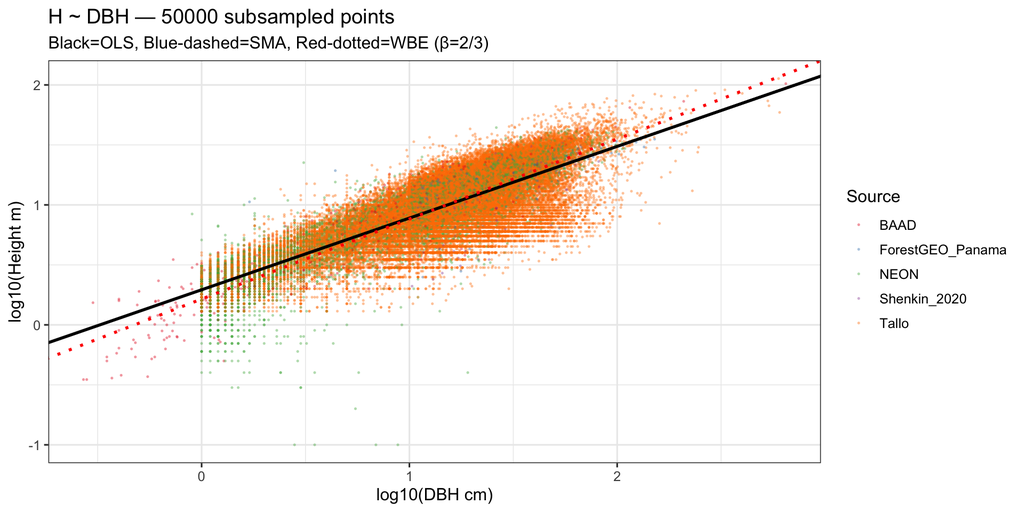

```r
set.seed(42)
plot_hd <- pool_hd |> sample_n(min(50000, n()))

ggplot(plot_hd, aes(log_dbh, log_h, colour = source)) +
  geom_point(size = 0.3, alpha = 0.3) +
  geom_abline(slope = as.numeric(ols_coef["log_dbh"]),
              intercept = as.numeric(ols_coef["(Intercept)"]),
              colour = "black", linewidth = 1, linetype = "solid") +
  {if (!is.null(sma_coef)) geom_abline(
              slope = as.numeric(sma_coef["slope"]),
              intercept = as.numeric(sma_coef["y-intercept"]),
              colour = "#1565C0", linewidth = 1, linetype = "dashed")} +
  geom_abline(slope = WBE_H_DBH,
              intercept = mean(plot_hd$log_h) - WBE_H_DBH * mean(plot_hd$log_dbh),
              colour = "red", linewidth = 1, linetype = "dotted") +
  scale_colour_brewer(palette = "Set1") +
  labs(title = paste0("H ~ DBH — ", nrow(plot_hd), " subsampled points"),
       subtitle = "Black=OLS, Blue-dashed=SMA, Red-dotted=WBE (β=2/3)",
       x = "log10(DBH cm)", y = "log10(Height m)", colour = "Source")
```

## 4.2 Study-level slopes

```r
study_hd <- pool_hd |>
  group_by(source) |>
  group_map(function(d, k) {
    if (nrow(d) < 5) return(NULL)
    o  <- lm(log_h ~ log_dbh, data = d)
    s  <- tryCatch(sma(log_h ~ log_dbh, data = d), error = function(e) NULL)
    ci <- confint(o, "log_dbh")
    se <- summary(o)$coefficients["log_dbh", "Std. Error"]
    tibble(
      source  = k$source,
      n       = nrow(d),
      ols_slope = coef(o)["log_dbh"],
      ols_ci_lo = ci[1], ols_ci_hi = ci[2],
      ols_se  = se,
      r2      = summary(o)$r.squared,
      sma_slope = if (!is.null(s)) as.numeric(coef(s)[[1]]["slope"]) else NA_real_)
  }) |> bind_rows()

if (HAS_METAFOR) {
  re_hd <- tryCatch(
    metafor::rma(yi = ols_slope, sei = ols_se, data = study_hd, method = "REML"),
    error = function(e) NULL)
} else {
  # Manual Cochran Q
  w     <- 1 / study_hd$ols_se^2
  wm    <- weighted.mean(study_hd$ols_slope, w)
  Q_hd  <- sum(w * (study_hd$ols_slope - wm)^2)
  df_hd <- nrow(study_hd) - 1
  I2_hd <- max(0, (Q_hd - df_hd) / Q_hd * 100)
  re_hd <- NULL
}

I2_report <- if (!is.null(re_hd) && HAS_METAFOR) {
  round(re_hd$I2, 1)
} else if (exists("I2_hd")) round(I2_hd, 1) else NA_real_

if (!is.na(I2_report)) cat(sprintf("H~DBH heterogeneity: I² = %.1f%%\n", I2_report)) else cat("H~DBH I² not estimable.\n")
```

```
## H~DBH heterogeneity: I² = 100.0%
```

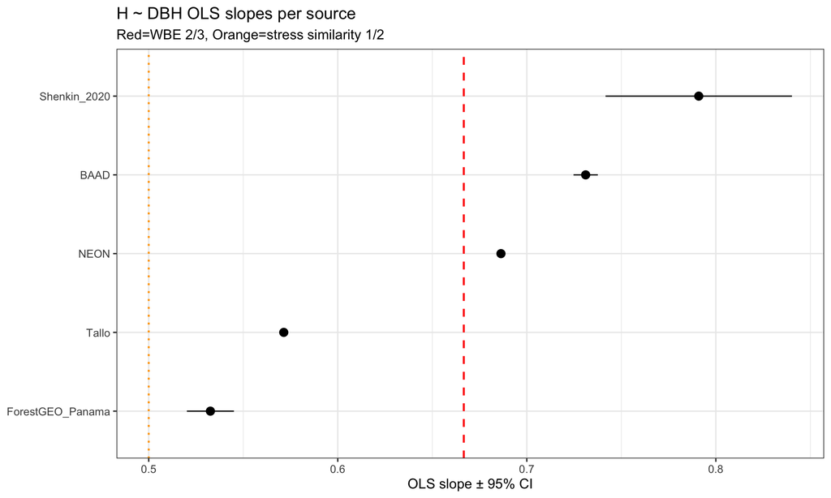

```r
study_hd |>
  mutate(source = reorder(source, ols_slope)) |>
  ggplot(aes(source, ols_slope)) +
  geom_pointrange(aes(ymin = ols_ci_lo, ymax = ols_ci_hi), size = 0.6) +
  geom_hline(yintercept = WBE_H_DBH, colour = "red", linetype = "dashed",
             linewidth = 0.8) +
  geom_hline(yintercept = STRESS_H_DBH, colour = "orange", linetype = "dotted",
             linewidth = 0.8) +
  coord_flip() +
  labs(title = "H ~ DBH OLS slopes per source",
       subtitle = "Red=WBE 2/3, Orange=stress similarity 1/2",
       x = NULL, y = "OLS slope ± 95% CI")
```

## 4.3 Gymnosperm vs Angiosperm

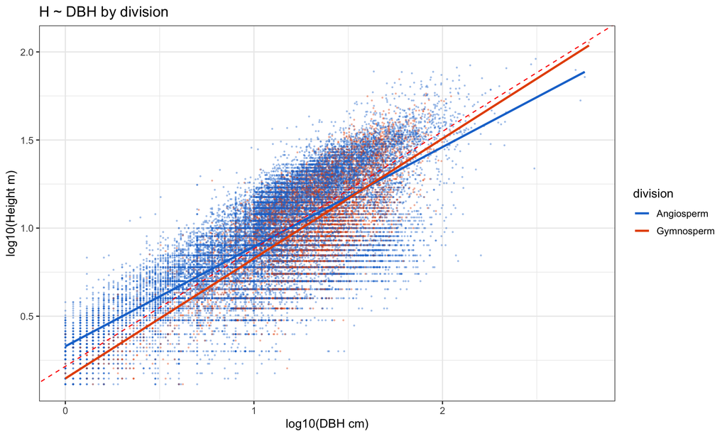

```r
pool_hd_div <- pool_hd |> filter(!is.na(division))
if (nrow(pool_hd_div) > 50) {
  div_fits <- pool_hd_div |>
    group_by(division) |>
    group_map(function(d, k) {
      o <- lm(log_h ~ log_dbh, data = d)
      s <- tryCatch(sma(log_h ~ log_dbh, data = d), error = function(e) NULL)
      tibble(division = k$division, n = nrow(d),
             ols_slope = coef(o)["log_dbh"],
             ci_lo = confint(o,"log_dbh")[1], ci_hi = confint(o,"log_dbh")[2],
             sma_slope = if (!is.null(s)) as.numeric(coef(s)[[1]]["slope"]) else NA_real_)
    }) |> bind_rows()

  kable(div_fits, digits = 3,
        caption = "H ~ DBH by division. WBE prediction = 2/3.")

  set.seed(42)
  pool_hd_div |>
    filter(division %in% c("Angiosperm","Gymnosperm")) |>
    sample_n(min(30000, n())) |>
    ggplot(aes(log_dbh, log_h, colour = division)) +
    geom_point(size = 0.3, alpha = 0.3) +
    geom_smooth(method = "lm", se = FALSE, linewidth = 1) +
    geom_abline(slope = WBE_H_DBH,
                intercept = mean(pool_hd$log_h) - WBE_H_DBH * mean(pool_hd$log_dbh),
                colour = "red", linetype = "dashed") +
    scale_colour_manual(values = c(Angiosperm = "#1976D2", Gymnosperm = "#E65100")) +
    labs(title = "H ~ DBH by division", x = "log10(DBH cm)", y = "log10(Height m)")
} else message("Insufficient division-labelled records.")
```

## 4.4 Family-level SMA forest plot

[figure not shown]

```r
sma_elig_fams <- fam_audit |> filter(sma_eligible) |> pull(family)

fam_hd_fits <- map_df(sma_elig_fams, function(fam) {
  d <- pool_hd |> filter(family == fam)
  if (nrow(d) < 10) return(NULL)
  s <- tryCatch(sma(log_h ~ log_dbh, data = d), error = function(e) NULL)
  if (is.null(s)) return(NULL)
  tibble(family = fam, n = nrow(d),
         slope  = as.numeric(coef(s)[[1]]["slope"]),
         ci_lo  = as.numeric(s$slopetest[[1]]$test["lower"]),
         ci_hi  = as.numeric(s$slopetest[[1]]$test["upper"]),
         division = unique(d$division[!is.na(d$division)])[1])
})

if (nrow(fam_hd_fits) > 0) {
  fam_hd_fits |>
    mutate(family = reorder(family, slope)) |>
    ggplot(aes(slope, family, colour = division)) +
    geom_pointrange(aes(xmin = ci_lo, xmax = ci_hi), size = 0.5) +
    geom_vline(xintercept = WBE_H_DBH, colour = "red",
               linetype = "dashed", linewidth = 0.8) +
    scale_colour_manual(values = c(Angiosperm = "#1976D2", Gymnosperm = "#E65100"),
                        na.value = "grey50") +
    labs(title = "Family-level SMA slopes — H ~ DBH",
         subtitle = "Red dashed = WBE 2/3",
         x = "SMA slope ± 95% CI", y = NULL, colour = "Division") +
    theme(axis.text.y = element_text(size = 8))
}
```

## 4.5 PGLS for H ~ DBH

```r
# Aggregate to species means across all direct-measurement sources
spp_hd <- allom |>
  filter(!is.na(DBH_cm), !is.na(Height_m), DBH_cm > 0, Height_m > 0,
         !is.na(species), !grepl("^sp\\.?$", species)) |>
  mutate(log_dbh = log10(DBH_cm), log_h = log10(Height_m)) |>
  group_by(species, family) |>
  summarise(log_dbh_m = mean(log_dbh, na.rm = TRUE),
            log_h_m   = mean(log_h, na.rm = TRUE),
            n = n(), .groups = "drop") |>
  filter(n >= 5, !is.na(species)) |>  # n >= 5 for reliable species means in PGLS
  mutate(sp_tree = gsub(" ", "_", species)) |>
  distinct(sp_tree, .keep_all = TRUE)

ols_pgls_hd <- lm(log_h_m ~ log_dbh_m, data = spp_hd)
sma_pgls_hd <- tryCatch(sma(log_h_m ~ log_dbh_m, data = spp_hd),
                         error = function(e) NULL)

if (HAS_PHYLOMAKER && nrow(spp_hd) > 20) {
  # Cap to 600 species for tractable phylogeny building; prefer higher-n species
  spp_hd_phy <- spp_hd |>
    filter(!is.na(family)) |>
    arrange(desc(n)) |>
    slice_head(n = 600)

  sp_list_hd <- spp_hd_phy |>
    mutate(genus_col = word(species, 1)) |>
    distinct(species, genus_col, family) |>
    rename(species_col = species)

  phy_hd <- tryCatch({
    res <- V.PhyloMaker2::phylo.maker(
      sp.list = data.frame(species = gsub(" ","_", sp_list_hd$species_col),
                           genus   = sp_list_hd$genus_col,
                           family  = sp_list_hd$family),
      tree      = V.PhyloMaker2::GBOTB.extended.WP,
      nodes     = V.PhyloMaker2::nodes.info.1.WP,
      scenarios = "S3")
    res$scenario.3
  }, error = function(e) {
    message("V.PhyloMaker2 failed — PGLS skipped (no valid phylogeny available).")
    NULL
  })

  if (!is.null(phy_hd)) {
    set.seed(42)
    phy_hd <- multi2di(phy_hd, random = TRUE)
    phy_hd <- phytools::force.ultrametric(phy_hd, method = "extend")
    phy_hd$node.label <- NULL

    pgls_df_hd <- spp_hd_phy |>
      filter(sp_tree %in% phy_hd$tip.label) |>
      distinct(sp_tree, .keep_all = TRUE) |>
      as.data.frame()
    rownames(pgls_df_hd) <- pgls_df_hd$sp_tree

    cd_hd <- tryCatch(
      caper::comparative.data(phy = phy_hd, data = pgls_df_hd,
                              names.col = "sp_tree", vcv = TRUE),
      error = function(e) NULL)

    if (!is.null(cd_hd)) {
    pgls_fit_hd <- tryCatch(
      caper::pgls(log_h_m ~ log_dbh_m, data = cd_hd,
                  lambda = "ML", bounds = list(lambda = c(1e-6, 1))),
      error = function(e) NULL)

    if (!is.null(pgls_fit_hd)) {
      pgls_slope  <- coef(pgls_fit_hd)["log_dbh_m"]
      pgls_se     <- sqrt(diag(pgls_fit_hd$VCV))["log_dbh_m"]
      pgls_ci     <- pgls_slope + c(-1, 1) *
                       qt(0.975, length(pgls_fit_hd$residuals) - 2) * pgls_se
      pgls_lambda <- pgls_fit_hd$param["lambda"]

      lp <- tryCatch(pgls.profile(pgls_fit_hd, which = "lambda"),
                     error = function(e) NULL)
      lambda_ci <- if (!is.null(lp)) tryCatch(pgls.confint(lp)$ci.val,
                                               error = function(e) c(NA, NA)) else c(NA, NA)

      pgls_r2 <- summary(pgls_fit_hd)$r.squared

      hd_pgls_table <- tibble(
        Method = c("OLS (spp means)","SMA (spp means)","PGLS"),
        Slope  = c(coef(ols_pgls_hd)["log_dbh_m"],
                   if (!is.null(sma_pgls_hd)) as.numeric(coef(sma_pgls_hd)[[1]]["slope"]) else NA_real_,
                   pgls_slope),
        CI_lo  = c(confint(ols_pgls_hd,"log_dbh_m")[1],
                   if (!is.null(sma_pgls_hd)) as.numeric(sma_pgls_hd$slopetest[[1]]$test["lower"]) else NA_real_,
                   pgls_ci[1]),
        CI_hi  = c(confint(ols_pgls_hd,"log_dbh_m")[2],
                   if (!is.null(sma_pgls_hd)) as.numeric(sma_pgls_hd$slopetest[[1]]$test["upper"]) else NA_real_,
                   pgls_ci[2]),
        Lambda = c(NA, NA, pgls_lambda),
        R2     = c(summary(ols_pgls_hd)$r.squared, NA_real_, pgls_r2))

      kable(hd_pgls_table, digits = 3,
            caption = paste0("H ~ DBH: OLS / SMA / PGLS comparison (N spp = ",
                             nrow(pgls_df_hd), "). WBE β = 2/3."))
    }
  }
  } # end if (!is.null(phy_hd))
} else {
  message("PGLS skipped (V.PhyloMaker2 unavailable or insufficient species).")
}
```

[output not shown]

H ~ DBH: OLS / SMA / PGLS comparison (N spp = 600). WBE β = 2/3.

| Method | Slope | CI_lo | CI_hi | Lambda | R2 |
| --- | --- | --- | --- | --- | --- |
| OLS (spp means) | 0.700 | 0.688 | 0.712 | NA | 0.778 |
| SMA (spp means) | NA | NA | NA | NA | NA |
| PGLS | 0.713 | NA | NA | 0.484 | 0.760 |

## 4.6 Intraspecific H ~ DBH slopes

```r
intra_hd <- pool_hd |>
  group_by(species, family) |>
  filter(n() >= 10,
         log10(max(DBH_cm) / pmax(min(DBH_cm), 1e-6)) >= 1.5) |>
  group_map(function(d, k) {
    o  <- lm(log_h ~ log_dbh, data = d)
    ci <- confint(o, "log_dbh")
    tibble(species = k$species, family = k$family,
           slope = coef(o)["log_dbh"],
           ci_lo = ci[1], ci_hi = ci[2],
           r2 = summary(o)$r.squared, n = nrow(d))
  }) |> bind_rows()

if (nrow(intra_hd) > 0) {
  t_intra_hd <- t.test(intra_hd$slope, mu = WBE_H_DBH)
  cat(sprintf("Intraspecific H~DBH: mean β = %.3f ± %.3f SD; t-test vs 2/3: p = %.4f\n",
              mean(intra_hd$slope), sd(intra_hd$slope), t_intra_hd$p.value))

  ggplot(intra_hd, aes(slope)) +
    geom_histogram(bins = 40, fill = "#42A5F5", colour = "white") +
    geom_vline(xintercept = WBE_H_DBH, colour = "red",
               linetype = "dashed", linewidth = 1) +
    geom_vline(xintercept = 1.0, colour = "grey40",
               linetype = "dotted", linewidth = 0.8) +
    labs(title = paste0("Intraspecific H ~ DBH slopes (N species = ",
                        nrow(intra_hd), ")"),
         subtitle = "Red=WBE 2/3, Grey=isometric 1.0",
         x = "OLS slope", y = "Count")

  kable(intra_hd |> arrange(desc(n)) |> head(20),
        digits = 3, caption = "Top 20 species by N (intraspecific H~DBH).")
}
```

```
## Intraspecific H~DBH: mean β = 0.623 ± 0.124 SD; t-test vs 2/3: p = 0.0000
```

Top 20 species by N (intraspecific H~DBH).

| species | family | slope | ci_lo | ci_hi | r2 | n |
| --- | --- | --- | --- | --- | --- | --- |
| Pinus sylvestris | Pinaceae | 0.580 | 0.570 | 0.589 | 0.455 | 17905 |
| Quercus infectoria | Fagaceae | 0.391 | 0.377 | 0.405 | 0.218 | 10915 |
| Acer rubrum L. | Aceraceae | 0.615 | 0.610 | 0.620 | 0.850 | 10639 |
| Fagus sylvatica | Fagaceae | 0.445 | 0.434 | 0.456 | 0.410 | 8931 |
| Pinus nigra | Pinaceae | 0.637 | 0.623 | 0.650 | 0.547 | 7363 |
| Picea abies | Pinaceae | 0.818 | 0.810 | 0.827 | 0.844 | 6685 |
| Acer saccharum | Sapindaceae | 0.567 | 0.559 | 0.574 | 0.793 | 5742 |
| Pseudotsuga menziesii | Pinaceae | 0.748 | 0.741 | 0.756 | 0.882 | 5144 |
| Quercus libani | Fagaceae | 0.385 | 0.369 | 0.402 | 0.291 | 5117 |
| Populus tremuloides Michx. | Salicaceae | 0.618 | 0.611 | 0.625 | 0.854 | 4926 |
| Quercus pubescens | Fagaceae | 0.387 | 0.372 | 0.403 | 0.363 | 4184 |
| Quercus pyrenaica | Fagaceae | 0.397 | 0.381 | 0.412 | 0.380 | 4128 |
| Tsuga canadensis (L.) Carrière | Pinaceae | 0.767 | 0.758 | 0.776 | 0.881 | 3770 |
| Pinus palustris Mill. | Pinaceae | 0.843 | 0.823 | 0.864 | 0.637 | 3678 |
| Acer rubrum | Sapindaceae | 0.641 | 0.633 | 0.650 | 0.860 | 3540 |
| Liquidambar styraciflua L. | Hamamelidaceae | 0.713 | 0.706 | 0.720 | 0.921 | 3240 |
| Abies balsamea (L.) Mill. | Pinaceae | 0.819 | 0.808 | 0.829 | 0.880 | 3220 |
| Acer saccharum Marshall | Aceraceae | 0.604 | 0.596 | 0.611 | 0.883 | 3175 |
| Fagus grandifolia Ehrh. | Fagaceae | 0.733 | 0.722 | 0.744 | 0.850 | 3061 |
| Abies balsamea | Pinaceae | 0.772 | 0.760 | 0.785 | 0.841 | 2929 |

# 5 AGB ~ DBH Scaling

```r
# Primary: BAAD only (direct AGB)
pool_agb_primary <- allom |>
  filter(agb_eligible, !is.na(DBH_cm), !is.na(AGB_kg),
         DBH_cm > 0, AGB_kg > 0) |>
  mutate(log_dbh = log10(DBH_cm), log_agb = log10(AGB_kg))

# Sensitivity: include NEON
pool_agb_all <- allom |>
  filter(!is.na(DBH_cm), !is.na(AGB_kg), DBH_cm > 0, AGB_kg > 0) |>
  mutate(log_dbh = log10(DBH_cm), log_agb = log10(AGB_kg))
```

## 5.1 Pooled AGB ~ DBH

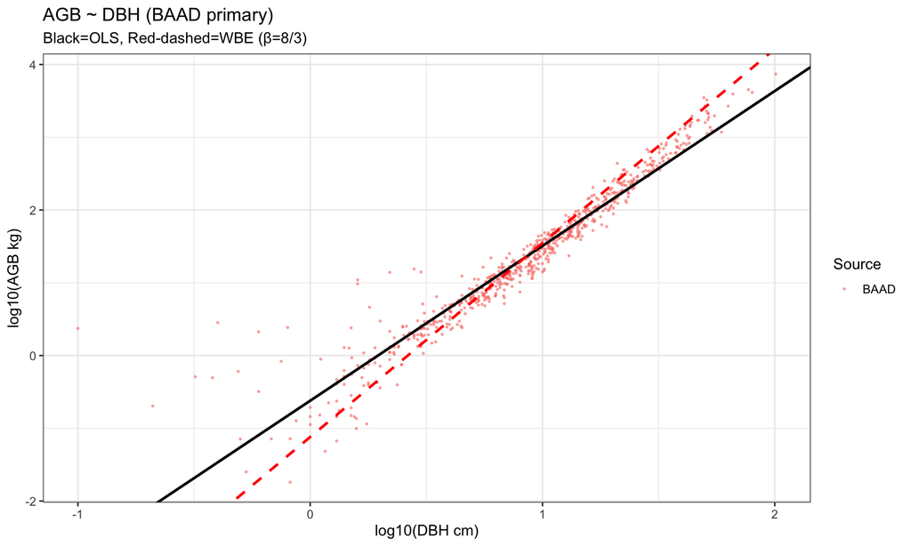

```r
if (nrow(pool_agb_primary) > 20) {
  ols_agb  <- lm(log_agb ~ log_dbh, data = pool_agb_primary)
  sma_agb  <- tryCatch(sma(log_agb ~ log_dbh, data = pool_agb_primary),
                        error = function(e) NULL)
  sma_test_agb <- tryCatch(
    slope.test(pool_agb_primary$log_agb, pool_agb_primary$log_dbh,
               test.value = WBE_AGB_DBH, method = "SMA"),
    error = function(e) list(p = NA_real_))

  agb_ci <- confint(ols_agb, "log_dbh")
  agb_table <- tibble(
    Method   = c("OLS (BAAD primary)","SMA (BAAD primary)"),
    Slope    = c(coef(ols_agb)["log_dbh"],
                 if (!is.null(sma_agb)) as.numeric(coef(sma_agb)[[1]]["slope"]) else NA_real_),
    CI_lo    = c(agb_ci[1],
                 if (!is.null(sma_agb)) as.numeric(sma_agb$slopetest[[1]]$test["lower"]) else NA_real_),
    CI_hi    = c(agb_ci[2],
                 if (!is.null(sma_agb)) as.numeric(sma_agb$slopetest[[1]]$test["upper"]) else NA_real_),
    R2       = c(summary(ols_agb)$r.squared, NA_real_),
    p_vs_WBE = c(
      2 * pt(abs((coef(ols_agb)["log_dbh"] - WBE_AGB_DBH) /
                   summary(ols_agb)$coefficients["log_dbh","Std. Error"]),
             df = df.residual(ols_agb), lower.tail = FALSE),
      sma_test_agb$p))

  kable(agb_table, digits = 3,
        caption = paste0("AGB ~ DBH pooled (N = ", nrow(pool_agb_primary),
                         " BAAD). WBE prediction β = 8/3 ≈ 2.667."))

  agb_coef <- coef(ols_agb)
  ggplot(pool_agb_primary |> sample_n(min(5000, n())),
         aes(log_dbh, log_agb, colour = source)) +
    geom_point(size = 0.5, alpha = 0.5) +
    geom_abline(slope = agb_coef["log_dbh"], intercept = agb_coef["(Intercept)"],
                colour = "black", linewidth = 1) +
    geom_abline(slope = WBE_AGB_DBH,
                intercept = mean(pool_agb_primary$log_agb) -
                            WBE_AGB_DBH * mean(pool_agb_primary$log_dbh),
                colour = "red", linetype = "dashed", linewidth = 1) +
    labs(title = "AGB ~ DBH (BAAD primary)",
         subtitle = "Black=OLS, Red-dashed=WBE (β=8/3)",
         x = "log10(DBH cm)", y = "log10(AGB kg)", colour = "Source")
} else {
  message("BAAD not available — AGB primary analysis skipped.")
}
```

## 5.2 Study-level AGB slopes

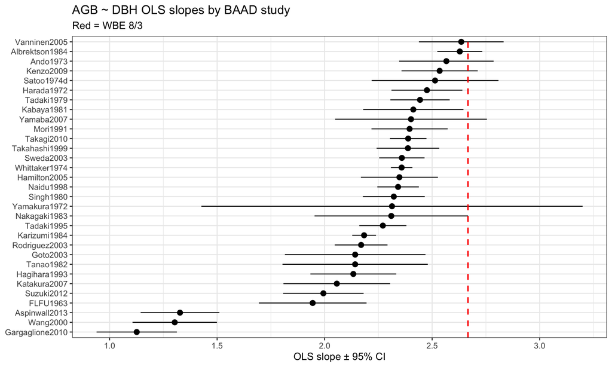

```r
if (HAS_BAAD && nrow(pool_agb_primary) > 20) {
  # Use baad_raw (cached in load-baad chunk) directly — avoids fragile paste-match
  baad_full <- baad_raw |>
    filter(!is.na(d.bh), !is.na(m.to), d.bh > 0, m.to > 0) |>
    mutate(log_dbh = log10(d.bh * 100), log_agb = log10(m.to))

  study_agb <- baad_full |>
    group_by(studyName) |>
    group_map(function(d, k) {
      if (nrow(d) < 5) return(NULL)
      o  <- lm(log_agb ~ log_dbh, data = d)
      ci <- confint(o, "log_dbh")
      tibble(studyName = k$studyName, n = nrow(d),
             slope = coef(o)["log_dbh"],
             ci_lo = ci[1], ci_hi = ci[2],
             r2 = summary(o)$r.squared)
    }) |> bind_rows()

  if (nrow(study_agb) > 1) {
    study_agb |>
      mutate(studyName = reorder(studyName, slope)) |>
      ggplot(aes(slope, studyName)) +
      geom_pointrange(aes(xmin = ci_lo, xmax = ci_hi), size = 0.5) +
      geom_vline(xintercept = WBE_AGB_DBH, colour = "red",
                 linetype = "dashed", linewidth = 0.8) +
      labs(title = "AGB ~ DBH OLS slopes by BAAD study",
           subtitle = "Red = WBE 8/3",
           x = "OLS slope ± 95% CI", y = NULL)
  }
}
```

## 5.3 Division comparison, family SMA, PGLS, intraspecific

```r
if (HAS_BAAD && nrow(pool_agb_primary) > 20) {
  pool_agb_div <- baad_raw |>
    filter(!is.na(d.bh), !is.na(m.to), d.bh > 0, m.to > 0) |>
    mutate(log_dbh = log10(d.bh * 100), log_agb = log10(m.to),
           family  = NA_character_)
  # Division info not in BAAD — skip division comparison for AGB
  message("BAAD lacks division annotation — AGB division comparison not available.")
}
```

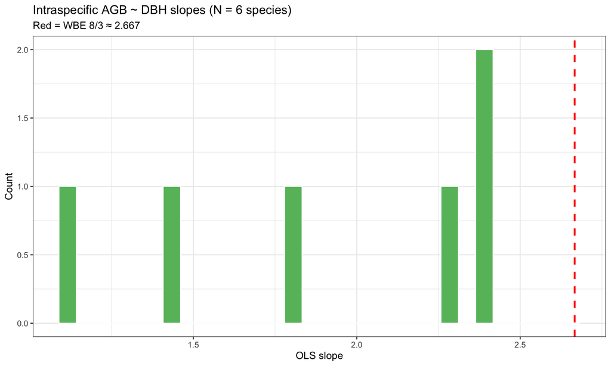

```r
if (HAS_BAAD && nrow(pool_agb_primary) > 50) {
  intra_agb <- pool_agb_primary |>
    filter(!is.na(species)) |>
    group_by(species) |>
    filter(n() >= 10,
           log10(max(DBH_cm) / pmax(min(DBH_cm), 1e-6)) >= 1.5) |>
    group_map(function(d, k) {
      o  <- lm(log_agb ~ log_dbh, data = d)
      ci <- confint(o, "log_dbh")
      tibble(species = k$species, slope = coef(o)["log_dbh"],
             ci_lo = ci[1], ci_hi = ci[2],
             r2 = summary(o)$r.squared, n = nrow(d))
    }) |> bind_rows()

  if (nrow(intra_agb) > 0) {
    ggplot(intra_agb, aes(slope)) +
      geom_histogram(bins = 30, fill = "#66BB6A", colour = "white") +
      geom_vline(xintercept = WBE_AGB_DBH, colour = "red",
                 linetype = "dashed", linewidth = 1) +
      labs(title = paste0("Intraspecific AGB ~ DBH slopes (N = ",
                          nrow(intra_agb), " species)"),
           subtitle = "Red = WBE 8/3 ≈ 2.667",
           x = "OLS slope", y = "Count")
  }
}
```

# 6 Crown Radius ~ DBH (Tallo)

```r
crown_dat <- tallo_clean |>
  filter(!is.na(CrownRadius_m), !is.na(DBH_cm),
         CrownRadius_m > 0, DBH_cm > 0) |>
  mutate(log_dbh = log10(DBH_cm), log_cr = log10(CrownRadius_m))
```

## 6.1 Pooled crown analysis

```r
if (nrow(crown_dat) > 100) {
  ols_cr  <- lm(log_cr ~ log_dbh, data = crown_dat)
  sma_cr  <- tryCatch(sma(log_cr ~ log_dbh, data = crown_dat),
                       error = function(e) NULL)
  sma_test_cr <- tryCatch(
    slope.test(crown_dat$log_cr, crown_dat$log_dbh,
               test.value = WBE_CROWN_DBH, method = "SMA"),
    error = function(e) list(p = NA_real_))

  cr_ci <- confint(ols_cr, "log_dbh")
  cr_table <- tibble(
    Method   = c("OLS","SMA"),
    Slope    = c(coef(ols_cr)["log_dbh"],
                 if (!is.null(sma_cr)) as.numeric(coef(sma_cr)[[1]]["slope"]) else NA_real_),
    CI_lo    = c(cr_ci[1],
                 if (!is.null(sma_cr)) as.numeric(sma_cr$slopetest[[1]]$test["lower"]) else NA_real_),
    CI_hi    = c(cr_ci[2],
                 if (!is.null(sma_cr)) as.numeric(sma_cr$slopetest[[1]]$test["upper"]) else NA_real_),
    R2       = c(summary(ols_cr)$r.squared, NA_real_),
    p_vs_WBE = c(
      2 * pt(abs((coef(ols_cr)["log_dbh"] - WBE_CROWN_DBH) /
                   summary(ols_cr)$coefficients["log_dbh","Std. Error"]),
             df = df.residual(ols_cr), lower.tail = FALSE),
      sma_test_cr$p))

  kable(cr_table, digits = 3,
        caption = paste0("Crown radius ~ DBH (N = ", nrow(crown_dat),
                         "). WBE pipe model β = 1.0."))
}
```

Crown radius ~ DBH (N = 312056). WBE pipe model β = 1.0.

| Method | Slope | CI_lo | CI_hi | R2 | p_vs_WBE |
| --- | --- | --- | --- | --- | --- |
| OLS | 0.627 | 0.626 | 0.629 | 0.603 | 0 |
| SMA | NA | NA | NA | NA | 0 |

## 6.2 Family SMA and division for crown

[figure not shown]

```r
if (nrow(crown_dat) > 100) {
  fam_cr_fits <- map_df(sma_elig_fams, function(fam) {
    d <- crown_dat |> filter(family == fam)
    if (nrow(d) < 10) return(NULL)
    s <- tryCatch(sma(log_cr ~ log_dbh, data = d), error = function(e) NULL)
    if (is.null(s)) return(NULL)
    tibble(family = fam, n = nrow(d),
           slope  = as.numeric(coef(s)[[1]]["slope"]),
           ci_lo  = as.numeric(s$slopetest[[1]]$test["lower"]),
           ci_hi  = as.numeric(s$slopetest[[1]]$test["upper"]))
  })

  if (nrow(fam_cr_fits) > 0) {
    fam_cr_fits |>
      mutate(family = reorder(family, slope)) |>
      ggplot(aes(slope, family)) +
      geom_pointrange(aes(xmin = ci_lo, xmax = ci_hi), size = 0.5) +
      geom_vline(xintercept = WBE_CROWN_DBH, colour = "red",
                 linetype = "dashed", linewidth = 0.8) +
      labs(title = "Family-level SMA — Crown radius ~ DBH",
           subtitle = "Red = WBE pipe model (β = 1.0)",
           x = "SMA slope ± 95% CI", y = NULL)
  }
}
```

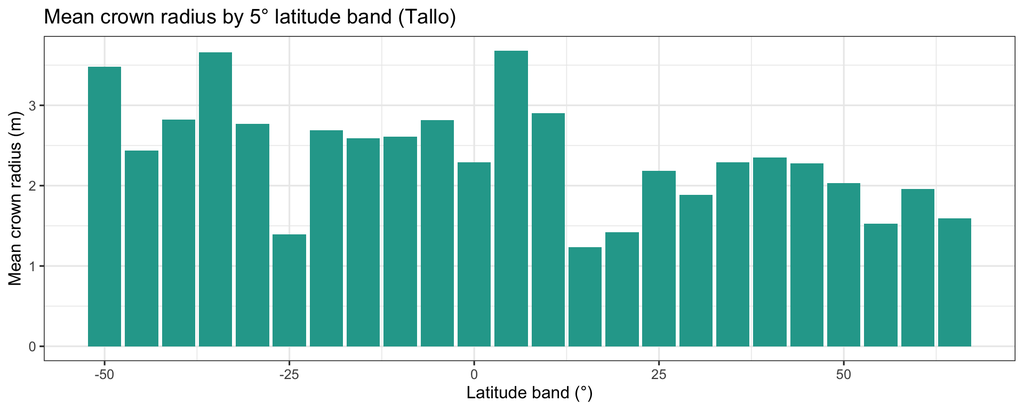

```r
tallo_crown_geo <- tallo_raw |>
  filter(!is.na(crown_radius_m), !is.na(latitude),
         crown_radius_outlier != "Y" | is.na(crown_radius_outlier)) |>
  mutate(lat_band = floor(latitude / 5) * 5) |>
  group_by(lat_band) |>
  summarise(mean_crown_r = mean(crown_radius_m, na.rm = TRUE),
            n = n(), .groups = "drop") |>
  filter(n >= 20)

ggplot(tallo_crown_geo, aes(lat_band, mean_crown_r)) +
  geom_col(fill = "#26A69A") +
  labs(title = "Mean crown radius by 5° latitude band (Tallo)",
       x = "Latitude band (°)", y = "Mean crown radius (m)")
```

# 7 Growth Rate Scaling (Niklas-Enquist)

```r
nik_pg <- nik_enq |>
  filter(pgls_eligible,
         !is.na(total_biomass_kg), total_biomass_kg > 0,
         !is.na(stem_growth_kgyr), stem_growth_kgyr > 0)
```

## 7.1 dM/dt ~ M (WBE: β = 3/4)

> ⚠️ **Growth rate caveat:** Growth rates in Niklas-Enquist are net annual biomass increment averages from Cannell (1982), not instantaneous metabolic rates. This does not constitute a direct test of WBE metabolic rate scaling (dM/dt ∝ M^0.75); net increment = gross production − maintenance respiration.

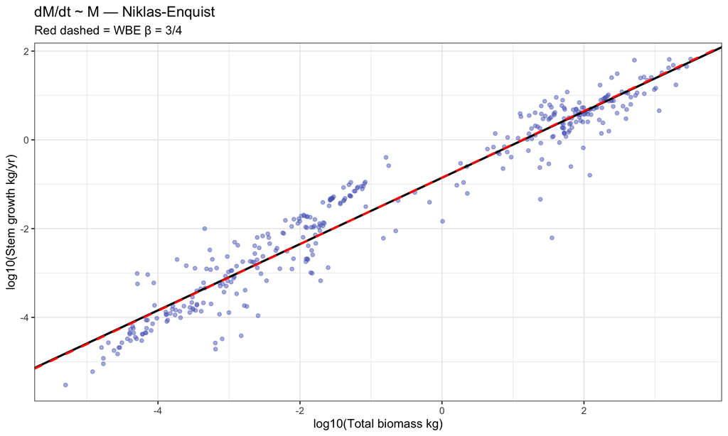

```r
if (nrow(nik_pg) > 10) {
  nik_pg2 <- nik_pg |>
    mutate(log_M     = log10(total_biomass_kg),
           log_dMdt  = log10(stem_growth_kgyr))

  ols_dM  <- lm(log_dMdt ~ log_M, data = nik_pg2)
  sma_dM  <- tryCatch(sma(log_dMdt ~ log_M, data = nik_pg2),
                       error = function(e) NULL)
  test_dM_75 <- tryCatch(
    slope.test(nik_pg2$log_dMdt, nik_pg2$log_M,
               test.value = WBE_GROWTH_M, method = "SMA"),
    error = function(e) list(p = NA_real_))
  test_dM_10 <- tryCatch(
    slope.test(nik_pg2$log_dMdt, nik_pg2$log_M,
               test.value = 1.0, method = "SMA"),
    error = function(e) list(p = NA_real_))

  dM_ci <- confint(ols_dM, "log_M")
  dM_table <- tibble(
    Method   = c("OLS","SMA"),
    Slope    = c(coef(ols_dM)["log_M"],
                 if (!is.null(sma_dM)) as.numeric(coef(sma_dM)[[1]]["slope"]) else NA_real_),
    CI_lo    = c(dM_ci[1],
                 if (!is.null(sma_dM)) as.numeric(sma_dM$slopetest[[1]]$test["lower"]) else NA_real_),
    CI_hi    = c(dM_ci[2],
                 if (!is.null(sma_dM)) as.numeric(sma_dM$slopetest[[1]]$test["upper"]) else NA_real_),
    p_vs_0.75 = c(
      2 * pt(abs((coef(ols_dM)["log_M"] - WBE_GROWTH_M) /
                   summary(ols_dM)$coefficients["log_M","Std. Error"]),
             df = df.residual(ols_dM), lower.tail = FALSE),
      test_dM_75$p),
    p_vs_1.0  = c(
      2 * pt(abs((coef(ols_dM)["log_M"] - 1.0) /
                   summary(ols_dM)$coefficients["log_M","Std. Error"]),
             df = df.residual(ols_dM), lower.tail = FALSE),
      test_dM_10$p))

  kable(dM_table, digits = 3,
        caption = paste0("dM/dt ~ M (N = ", nrow(nik_pg2),
                         " pgls-eligible). WBE β = 3/4; test also vs β = 1."))

  dM_coef <- coef(ols_dM)
  ggplot(nik_pg2, aes(log_M, log_dMdt)) +
    geom_point(alpha = 0.5, colour = "#5C6BC0") +
    geom_abline(slope = dM_coef["log_M"], intercept = dM_coef["(Intercept)"],
                colour = "black", linewidth = 1) +
    geom_abline(slope = WBE_GROWTH_M,
                intercept = mean(nik_pg2$log_dMdt) -
                            WBE_GROWTH_M * mean(nik_pg2$log_M),
                colour = "red", linetype = "dashed", linewidth = 1) +
    labs(title = "dM/dt ~ M — Niklas-Enquist",
         subtitle = "Red dashed = WBE β = 3/4",
         x = "log10(Total biomass kg)", y = "log10(Stem growth kg/yr)")
}
```

## 7.2 dM/dt ~ Height

```
## dM/dt ~ H: OLS slope = 1.749 (WBE prediction: H ∝ M^(1/4) → dM/dt ~ H^3, expected = 3.0)
```

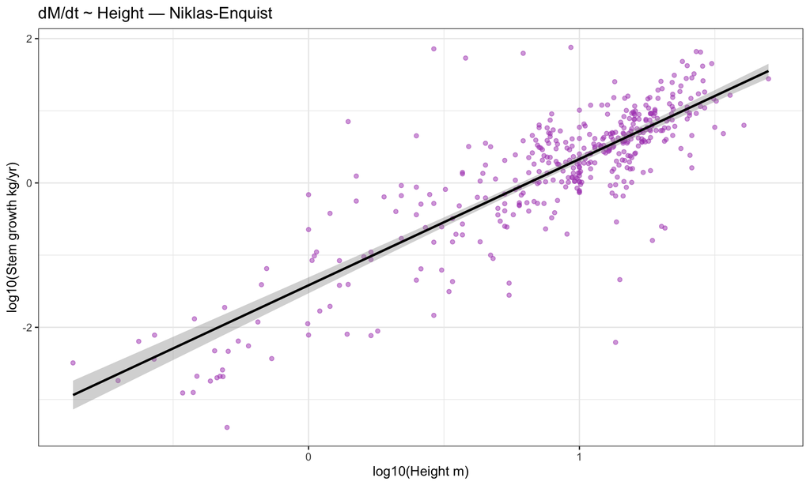

```r
nik_h <- nik_enq |>
  filter(pgls_eligible, !is.na(height_m), height_m > 0,
         !is.na(stem_growth_kgyr), stem_growth_kgyr > 0) |>
  mutate(log_h = log10(height_m), log_dMdt = log10(stem_growth_kgyr))

if (nrow(nik_h) > 10) {
  ols_h_dM <- lm(log_dMdt ~ log_h, data = nik_h)
  sma_h_dM <- tryCatch(sma(log_dMdt ~ log_h, data = nik_h),
                        error = function(e) NULL)
  # WBE chain: H \u221d M^(1/4) \u2192 dM/dt \u221d M^(3/4) \u221d H^3; WBE predicted exponent = 3
  cat(sprintf("dM/dt ~ H: OLS slope = %.3f (WBE prediction: H \u221d M^(1/4) \u2192 dM/dt ~ H^3, expected = 3.0)\n",
              coef(ols_h_dM)["log_h"]))
  ggplot(nik_h, aes(log_h, log_dMdt)) +
    geom_point(alpha = 0.5, colour = "#AB47BC") +
    geom_smooth(method = "lm", colour = "black", se = TRUE) +
    labs(title = "dM/dt ~ Height — Niklas-Enquist",
         x = "log10(Height m)", y = "log10(Stem growth kg/yr)")
}
```

## 7.3 Leaf biomass ~ Total biomass (coupling-corrected)

> ⚠️ **Mathematical coupling caveat:** When a component (leaf biomass) is regressed against the total that includes it, the correlation is partly artifactual (Pearson 1897). The corrected denominator uses total − leaf to avoid this artifact.

```r
nik_bt <- nik_enq |>
  filter(pgls_eligible,
         !is.na(leaf_biomass_kg), leaf_biomass_kg > 0,
         !is.na(total_biomass_kg), total_biomass_kg > 0) |>
  mutate(other_biomass = total_biomass_kg - leaf_biomass_kg) |>
  filter(other_biomass > 0) |>
  mutate(log_leaf  = log10(leaf_biomass_kg),
         log_other = log10(other_biomass),
         log_total = log10(total_biomass_kg))

if (nrow(nik_bt) > 10) {
  ols_leaf_corr  <- lm(log_leaf ~ log_other, data = nik_bt)
  ols_leaf_naive <- lm(log_leaf ~ log_total, data = nik_bt)
  sma_leaf_corr  <- tryCatch(sma(log_leaf ~ log_other, data = nik_bt),
                              error = function(e) NULL)
  test_leaf_corr <- tryCatch(
    slope.test(nik_bt$log_leaf, nik_bt$log_other,
               test.value = WBE_LEAF_TOTAL, method = "SMA"),
    error = function(e) list(p = NA_real_))

  leaf_ci <- confint(ols_leaf_corr, "log_other")
  leaf_table <- tibble(
    Model     = c("Corrected (leaf ~ other)", "Naive (leaf ~ total)"),
    Slope     = c(coef(ols_leaf_corr)["log_other"],
                  coef(ols_leaf_naive)["log_total"]),
    CI_lo     = c(leaf_ci[1], confint(ols_leaf_naive,"log_total")[1]),
    CI_hi     = c(leaf_ci[2], confint(ols_leaf_naive,"log_total")[2]),
    R2        = c(summary(ols_leaf_corr)$r.squared,
                  summary(ols_leaf_naive)$r.squared),
    p_vs_WBE  = c(
      2 * pt(abs((coef(ols_leaf_corr)["log_other"] - WBE_LEAF_TOTAL) /
                   summary(ols_leaf_corr)$coefficients["log_other","Std. Error"]),
             df = df.residual(ols_leaf_corr), lower.tail = FALSE),
      NA_real_))

  kable(leaf_table, digits = 3,
        caption = paste0("Leaf ~ Total biomass (N = ", nrow(nik_bt),
                         "). WBE prediction β = 3/4."))
}
```

Leaf ~ Total biomass (N = 633). WBE prediction β = 3/4.

| Model | Slope | CI_lo | CI_hi | R2 | p_vs_WBE |
| --- | --- | --- | --- | --- | --- |
| Corrected (leaf ~ other) | 0.784 | 0.773 | 0.795 | 0.969 | 0 |
| Naive (leaf ~ total) | 0.817 | 0.807 | 0.828 | 0.975 | NA |

## 7.4 Stem and Root biomass ~ Total

```r
nik_stem <- nik_enq |>
  filter(pgls_eligible, !is.na(stem_biomass_kg), stem_biomass_kg > 0,
         !is.na(total_biomass_kg), total_biomass_kg > 0) |>
  mutate(other = total_biomass_kg - stem_biomass_kg) |>
  filter(other > 0) |>
  mutate(log_stem = log10(stem_biomass_kg), log_other = log10(other))

if (nrow(nik_stem) > 10) {
  ols_stem <- lm(log_stem ~ log_other, data = nik_stem)
  test_stem <- tryCatch(
    slope.test(nik_stem$log_stem, nik_stem$log_other,
               test.value = WBE_STEM_TOTAL, method = "SMA"),
    error = function(e) list(p = NA_real_))
  cat(sprintf("Stem ~ (Total-stem): OLS slope = %.3f; p vs WBE 1.0 (SMA) = %.4f\n",
              coef(ols_stem)["log_other"], test_stem$p))
}
```

```
## Stem ~ (Total-stem): OLS slope = 1.186; p vs WBE 1.0 (SMA) = 0.0000
```

```r
nik_root <- nik_enq |>
  filter(pgls_eligible, !is.na(root_biomass_kg), root_biomass_kg > 0,
         !is.na(total_biomass_kg), total_biomass_kg > 0) |>
  mutate(other = total_biomass_kg - root_biomass_kg) |>
  filter(other > 0) |>
  mutate(log_root = log10(root_biomass_kg), log_other = log10(other))

if (nrow(nik_root) > 10) {
  ols_root <- lm(log_root ~ log_other, data = nik_root)
  cat(sprintf("Root ~ (Total-root): OLS slope = %.3f\n",
              coef(ols_root)["log_other"]))
}
```

```
## Root ~ (Total-root): OLS slope = 0.949
```

## 7.5 Niklas-Enquist summary table

```r
nik_summary <- tibble(
  Relationship      = c("dM/dt ~ M","Leaf ~ Total","Stem ~ Total","Root ~ Total"),
  WBE_prediction    = c("3/4","3/4","1","NA"),
  OLS_slope         = c(
    if (exists("ols_dM"))   round(coef(ols_dM)["log_M"],       3) else NA_real_,
    if (exists("ols_leaf_corr")) round(coef(ols_leaf_corr)["log_other"], 3) else NA_real_,
    if (exists("ols_stem")) round(coef(ols_stem)["log_other"], 3) else NA_real_,
    if (exists("ols_root")) round(coef(ols_root)["log_other"], 3) else NA_real_),
  SMA_slope         = c(
    if (exists("sma_dM") && !is.null(sma_dM)) round(as.numeric(coef(sma_dM)[[1]]["slope"]), 3) else NA_real_,
    if (exists("sma_leaf_corr") && !is.null(sma_leaf_corr)) round(as.numeric(coef(sma_leaf_corr)[[1]]["slope"]), 3) else NA_real_,
    NA_real_, NA_real_),
  p_vs_WBE_SMA      = c(
    if (exists("test_dM_75"))   round(test_dM_75$p, 4)   else NA_real_,
    if (exists("test_leaf_corr")) round(test_leaf_corr$p, 4) else NA_real_,
    if (exists("test_stem"))    round(test_stem$p, 4)    else NA_real_,
    NA_real_))

kable(nik_summary, digits = 3,
      caption = "Summary of Niklas-Enquist scaling relationships vs WBE predictions.")
```

Summary of Niklas-Enquist scaling relationships vs WBE predictions.

| Relationship | WBE_prediction | OLS_slope | SMA_slope | p_vs_WBE_SMA |
| --- | --- | --- | --- | --- |
| dM/dt ~ M | 3/4 | 0.747 | NA | 0.032 |
| Leaf ~ Total | 3/4 | 0.784 | NA | 0.000 |
| Stem ~ Total | 1 | 1.186 | NA | 0.000 |
| Root ~ Total | NA | 0.949 | NA | NA |

# 8 Niklas-Enquist WBE & MST Analysis: Complete Assessment

> **Theoretical basis:** West, Brown & Enquist (1997) *Science* 276:122; West et al. (1999) *Science* 284:1677; Niklas & Enquist (2001) *PNAS* 98:2922 (DOI: 10.1073/pnas.041590298); Enquist & Niklas (2002) *Science* 295:1517 (DOI: 10.1126/science.1066360). WBE predicts: metabolic rate B ∝ M^(3/4); leaf biomass ∝ non-photosynthetic biomass^(3/4); total growth rate ∝ M^(3/4). Enquist & Niklas (2002) extend this to full biomass partitioning — leaf ~ stem^(3/4) is the central cross-species prediction.

## 8.1 Taxonomy parsing and division assignment

```r
# ── Genus-to-family-and-division lookup ──────────────────────────────────────
# Family assignments follow APG IV (Chase et al. 2016, Bot J Linn Soc 181:1);
# gymnosperm orders follow Christenhusz et al. (2011). UNVERIFIED: DOIs not
# checked against Crossref.
ne_genus_lookup <- tibble::tribble(
  ~genus,            ~ne_family,         ~ne_division,
  "Abies",           "Pinaceae",         "Gymnosperm",
  "Picea",           "Pinaceae",         "Gymnosperm",
  "Pinus",           "Pinaceae",         "Gymnosperm",
  "Pseudotsuga",     "Pinaceae",         "Gymnosperm",
  "Larix",           "Pinaceae",         "Gymnosperm",
  "Tsuga",           "Pinaceae",         "Gymnosperm",
  "Cedrus",          "Pinaceae",         "Gymnosperm",
  "Keteleeria",      "Pinaceae",         "Gymnosperm",
  "Juniperus",       "Cupressaceae",     "Gymnosperm",
  "Thuja",           "Cupressaceae",     "Gymnosperm",
  "Cupressus",       "Cupressaceae",     "Gymnosperm",
  "Sequoia",         "Cupressaceae",     "Gymnosperm",
  "Sequoiadendron",  "Cupressaceae",     "Gymnosperm",
  "Taxodium",        "Cupressaceae",     "Gymnosperm",
  "Chamaecyparis",   "Cupressaceae",     "Gymnosperm",
  "Cryptomeria",     "Cupressaceae",     "Gymnosperm",
  "Metasequoia",     "Cupressaceae",     "Gymnosperm",
  "Podocarpus",      "Podocarpaceae",    "Gymnosperm",
  "Dacrydium",       "Podocarpaceae",    "Gymnosperm",
  "Araucaria",       "Araucariaceae",    "Gymnosperm",
  "Agathis",         "Araucariaceae",    "Gymnosperm",
  "Taxus",           "Taxaceae",         "Gymnosperm",
  "Ginkgo",          "Ginkgoaceae",      "Gymnosperm",
  "Cycas",           "Cycadaceae",       "Gymnosperm",
  "Ephedra",         "Ephedraceae",      "Gymnosperm",
  "Quercus",         "Fagaceae",         "Angiosperm",
  "Fagus",           "Fagaceae",         "Angiosperm",
  "Castanea",        "Fagaceae",         "Angiosperm",
  "Castanopsis",     "Fagaceae",         "Angiosperm",
  "Lithocarpus",     "Fagaceae",         "Angiosperm",
  "Nothofagus",      "Nothofagaceae",    "Angiosperm",
  "Betula",          "Betulaceae",       "Angiosperm",
  "Alnus",           "Betulaceae",       "Angiosperm",
  "Carpinus",        "Betulaceae",       "Angiosperm",
  "Corylus",         "Betulaceae",       "Angiosperm",
  "Ostrya",          "Betulaceae",       "Angiosperm",
  "Populus",         "Salicaceae",       "Angiosperm",
  "Salix",           "Salicaceae",       "Angiosperm",
  "Eucalyptus",      "Myrtaceae",        "Angiosperm",
  "Melaleuca",       "Myrtaceae",        "Angiosperm",
  "Acacia",          "Fabaceae",         "Angiosperm",
  "Robinia",         "Fabaceae",         "Angiosperm",
  "Prosopis",        "Fabaceae",         "Angiosperm",
  "Leucaena",        "Fabaceae",         "Angiosperm",
  "Gleditsia",       "Fabaceae",         "Angiosperm",
  "Tilia",           "Malvaceae",        "Angiosperm",
  "Fraxinus",        "Oleaceae",         "Angiosperm",
  "Olea",            "Oleaceae",         "Angiosperm",
  "Ulmus",           "Ulmaceae",         "Angiosperm",
  "Zelkova",         "Ulmaceae",         "Angiosperm",
  "Acer",            "Sapindaceae",      "Angiosperm",
  "Platanus",        "Platanaceae",      "Angiosperm",
  "Juglans",         "Juglandaceae",     "Angiosperm",
  "Carya",           "Juglandaceae",     "Angiosperm",
  "Magnolia",        "Magnoliaceae",     "Angiosperm",
  "Liriodendron",    "Magnoliaceae",     "Angiosperm",
  "Cinnamomum",      "Lauraceae",        "Angiosperm",
  "Shorea",          "Dipterocarpaceae", "Angiosperm",
  "Dipterocarpus",   "Dipterocarpaceae", "Angiosperm",
  "Swietenia",       "Meliaceae",        "Angiosperm",
  "Cedrela",         "Meliaceae",        "Angiosperm",
  "Ficus",           "Moraceae",         "Angiosperm",
  "Rhizophora",      "Rhizophoraceae",   "Angiosperm",
  "Avicennia",       "Acanthaceae",      "Angiosperm",
  "Casuarina",       "Casuarinaceae",    "Angiosperm",
  "Prunus",          "Rosaceae",         "Angiosperm",
  "Sorbus",          "Rosaceae",         "Angiosperm",
  "Malus",           "Rosaceae",         "Angiosperm",
  "Crataegus",       "Rosaceae",         "Angiosperm",
  "Cornus",          "Cornaceae",        "Angiosperm",
  "Liquidambar",     "Altingiaceae",     "Angiosperm",
  "Nyssa",           "Nyssaceae",        "Angiosperm",
  "Celtis",          "Cannabaceae",      "Angiosperm"
) |> dplyr::distinct(genus, .keep_all = TRUE)

# ── Name cleaning function ────────────────────────────────────────────────────
ne_parse_taxa <- function(taxa_vec) {
  cleaned <- taxa_vec |>
    stringr::str_trim() |>
    stringr::str_squish() |>
    stringr::str_remove_all("\\s*\\([^)]*\\)") |>
    stringr::str_remove("\\s*\\[[^\\]]*\\]$") |>
    stringr::str_remove("\\s+(ssp\\.|subsp\\.|var\\.|f\\.|cv\\.)\\s+\\S+.*$") |>
    stringr::str_remove("(?i)\\s+sp+\\.?\\s*$") |>
    stringr::str_trim()

  genus_vec  <- stringr::word(cleaned, 1)
  second_wd  <- stringr::word(cleaned, 2)
  has_epi    <- !is.na(second_wd) &
    stringr::str_detect(second_wd, "^[a-z][a-z\\-]+$") &
    !second_wd %in% c("sp", "spp", "sp.", "spp.")

  binomial <- dplyr::if_else(has_epi, paste(genus_vec, second_wd), NA_character_)

  flag_community <- stringr::str_detect(
    taxa_vec, stringr::regex("community|stand|mixed|plot|forest|woodland",
                              ignore_case = TRUE))

  dplyr::tibble(
    taxa_orig      = taxa_vec,
    taxa_cleaned   = cleaned,
    binomial       = binomial,
    genus          = genus_vec,
    flag_sp_only   = !has_epi & !is.na(genus_vec),
    flag_community = flag_community,
    flag_uncertain = is.na(binomial) | flag_community
  )
}

ne_parsed <- ne_parse_taxa(nik_enq$taxa) |>
  dplyr::left_join(ne_genus_lookup, by = "genus")

taxa_diag <- ne_parsed |>
  dplyr::count(ne_division, flag_uncertain, name = "n_records") |>
  dplyr::arrange(ne_division)
kable(taxa_diag, caption = "Niklas-Enquist taxonomy parsing diagnostics by division.")
```

Niklas-Enquist taxonomy parsing diagnostics by division.

| ne_division | flag_uncertain | n_records |
| --- | --- | --- |
| Angiosperm | FALSE | 375 |
| Angiosperm | TRUE | 133 |
| Gymnosperm | FALSE | 567 |
| Gymnosperm | TRUE | 44 |
| NA | FALSE | 1137 |
| NA | TRUE | 370 |

```r
cat(sprintf(
  "Gymnosperms: %d records | Angiosperms: %d records | NA division: %d | Uncertain (communities/sp-only): %d\n",
  sum(ne_parsed$ne_division == "Gymnosperm", na.rm = TRUE),
  sum(ne_parsed$ne_division == "Angiosperm", na.rm = TRUE),
  sum(is.na(ne_parsed$ne_division)),
  sum(ne_parsed$flag_uncertain)))
```

```
## Gymnosperms: 611 records | Angiosperms: 508 records | NA division: 1507 | Uncertain (communities/sp-only): 547
```

## 8.2 Species-means aggregation

```r
# Merge taxonomy back onto NE data (pgls_eligible records only)
ne_annotated <- nik_enq |>
  dplyr::mutate(taxa_orig = taxa) |>
  dplyr::left_join(
    ne_parsed |> dplyr::select(taxa_orig, binomial, genus,
                                ne_family, ne_division,
                                flag_uncertain, flag_sp_only),
    by = c("taxa" = "taxa_orig")) |>
  dplyr::filter(pgls_eligible, !flag_uncertain, !is.na(binomial),
                !is.na(total_biomass_kg), total_biomass_kg > 0) |>
  dplyr::mutate(
    non_leaf_kg  = dplyr::if_else(!is.na(leaf_biomass_kg)  & leaf_biomass_kg  > 0 &
                                    total_biomass_kg > leaf_biomass_kg,
                                  total_biomass_kg - leaf_biomass_kg,  NA_real_),
    non_root_kg  = dplyr::if_else(!is.na(root_biomass_kg)  & root_biomass_kg  > 0 &
                                    total_biomass_kg > root_biomass_kg,
                                  total_biomass_kg - root_biomass_kg,  NA_real_),
    non_stem_kg  = dplyr::if_else(!is.na(stem_biomass_kg)  & stem_biomass_kg  > 0 &
                                    total_biomass_kg > stem_biomass_kg,
                                  total_biomass_kg - stem_biomass_kg,  NA_real_)
  )

ne_sp_means <- ne_annotated |>
  dplyr::group_by(binomial, genus, ne_family, ne_division) |>
  dplyr::summarise(
    log_height_m          = mean(log10(pmax(height_m,         1e-9)), na.rm = TRUE),
    log_total_biomass_kg  = mean(log10(pmax(total_biomass_kg, 1e-9)), na.rm = TRUE),
    log_stem_biomass_kg   = mean(log10(pmax(stem_biomass_kg,  1e-9)[stem_biomass_kg  > 0 & !is.na(stem_biomass_kg)]),  na.rm = TRUE),
    log_leaf_biomass_kg   = mean(log10(pmax(leaf_biomass_kg,  1e-9)[leaf_biomass_kg  > 0 & !is.na(leaf_biomass_kg)]),  na.rm = TRUE),
    log_root_biomass_kg   = mean(log10(pmax(root_biomass_kg,  1e-9)[root_biomass_kg  > 0 & !is.na(root_biomass_kg)]),  na.rm = TRUE),
    log_shoot_biomass_kg  = mean(log10(pmax(shoot_biomass_kg, 1e-9)[shoot_biomass_kg > 0 & !is.na(shoot_biomass_kg)]), na.rm = TRUE),
    log_stem_growth_kgyr  = mean(log10(pmax(stem_growth_kgyr, 1e-9)[stem_growth_kgyr > 0 & !is.na(stem_growth_kgyr)]),  na.rm = TRUE),
    log_total_growth_kgyr = mean(log10(pmax(total_growth_kgyr,1e-9)[total_growth_kgyr> 0 & !is.na(total_growth_kgyr)]), na.rm = TRUE),
    log_non_leaf_kg       = mean(log10(pmax(non_leaf_kg, 1e-9)[non_leaf_kg > 0 & !is.na(non_leaf_kg)]), na.rm = TRUE),
    log_non_root_kg       = mean(log10(pmax(non_root_kg, 1e-9)[non_root_kg > 0 & !is.na(non_root_kg)]), na.rm = TRUE),
    log_non_stem_kg       = mean(log10(pmax(non_stem_kg, 1e-9)[non_stem_kg > 0 & !is.na(non_stem_kg)]), na.rm = TRUE),
    n_obs                 = dplyr::n(),
    .groups               = "drop"
  ) |>
  dplyr::mutate(
    across(starts_with("log_"), ~ ifelse(is.nan(.) | is.infinite(.), NA_real_, .)),
    singleton = (n_obs == 1L),
    sp_tree   = gsub(" ", "_", binomial)
  )

cat(sprintf("ne_sp_means: %d species — Gymno: %d, Angio: %d, NA division: %d\n",
  nrow(ne_sp_means),
  sum(ne_sp_means$ne_division == "Gymnosperm", na.rm = TRUE),
  sum(ne_sp_means$ne_division == "Angiosperm", na.rm = TRUE),
  sum(is.na(ne_sp_means$ne_division))))
```

```
## ne_sp_means: 81 species — Gymno: 18, Angio: 22, NA division: 41
```

```r
# Coverage by variable
cov_tbl <- ne_sp_means |>
  dplyr::summarise(across(starts_with("log_"), ~ sum(!is.na(.)))) |>
  tidyr::pivot_longer(everything(), names_to = "variable", values_to = "n_species")
kable(cov_tbl, caption = "Number of species with valid data per log-variable (ne_sp_means).")
```

Number of species with valid data per log-variable (ne_sp_means).

| variable | n_species |
| --- | --- |
| log_height_m | 52 |
| log_total_biomass_kg | 81 |
| log_stem_biomass_kg | 81 |
| log_leaf_biomass_kg | 81 |
| log_root_biomass_kg | 81 |
| log_shoot_biomass_kg | 81 |
| log_stem_growth_kgyr | 61 |
| log_total_growth_kgyr | 48 |
| log_non_leaf_kg | 81 |
| log_non_root_kg | 81 |
| log_non_stem_kg | 81 |

## 8.3 Phylogeny for Niklas-Enquist PGLS

```r
ne_pgls_tree <- NULL

if (HAS_PHYLOMAKER && nrow(ne_sp_means) >= 20) {
  sp_list_ne <- ne_sp_means |>
    dplyr::filter(!is.na(binomial), !is.na(ne_family)) |>
    dplyr::select(species = binomial, genus, family = ne_family) |>
    dplyr::distinct(species, .keep_all = TRUE)

  set.seed(42)
  ne_tree_out <- tryCatch({
    V.PhyloMaker2::phylo.maker(
      sp.list   = sp_list_ne,
      tree      = V.PhyloMaker2::GBOTB.extended.WP,
      nodes     = V.PhyloMaker2::nodes.info.1.WP,
      scenarios = "S3")
  }, error = function(e) {
    message("ne_pgls_tree: phylo.maker S3 failed — ", conditionMessage(e))
    NULL
  })

  if (!is.null(ne_tree_out)) {
    ne_pgls_tree <- ne_tree_out$scenario.3
    set.seed(42)
    ne_pgls_tree <- ape::multi2di(ne_pgls_tree, random = TRUE)
    if (!ape::is.ultrametric(ne_pgls_tree, tol = 1e-5))
      ne_pgls_tree <- phytools::force.ultrametric(ne_pgls_tree, method = "extend")
    ne_pgls_tree$node.label <- NULL

    n_tree_tips <- ape::Ntip(ne_pgls_tree)
    n_matched   <- sum(gsub(" ", "_", sp_list_ne$species) %in% ne_pgls_tree$tip.label)
    pct_match   <- round(100 * n_matched / nrow(sp_list_ne), 1)
    cat(sprintf("NE phylogeny: %d tips; %d/%d species matched (%.1f%%).\n",
                n_tree_tips, n_matched, nrow(sp_list_ne), pct_match))
    if (pct_match < 70)
      warning(sprintf("Only %.1f%% of NE species matched to tree.", pct_match))
  }
} else {
  message("PGLS skipped for NE dataset: V.PhyloMaker2 unavailable or < 20 species.")
}
```

```
## NE phylogeny: 40 tips; 40/40 species matched (100.0%).
```

## 8.4 Phylogenetic signal in NE biomass traits

```r
if (!is.null(ne_pgls_tree)) {
  ne_sig_df <- ne_sp_means |>
    dplyr::filter(sp_tree %in% ne_pgls_tree$tip.label) |>
    as.data.frame()

  ne_sig_rows <- purrr::map_dfr(
    c("log_total_biomass_kg", "log_stem_biomass_kg",
      "log_leaf_biomass_kg",  "log_root_biomass_kg",
      "log_height_m",         "log_total_growth_kgyr"),
    function(trait) {
      vals <- setNames(ne_sig_df[[trait]], ne_sig_df$sp_tree)
      vals <- vals[is.finite(vals)]
      if (length(vals) < 5) return(NULL)
      tr2  <- ape::keep.tip(ne_pgls_tree, names(vals))
      vals <- vals[tr2$tip.label]
      lam  <- tryCatch(phytools::phylosig(tr2, vals, method = "lambda", test = TRUE),
                       error = function(e) list(lambda = NA_real_, P = NA_real_))
      K    <- tryCatch(phytools::phylosig(tr2, vals, method = "K",      test = TRUE),
                       error = function(e) list(K = NA_real_, P = NA_real_))
      tibble::tibble(
        trait    = trait,
        N        = length(vals),
        lambda   = if (is.list(lam)) lam$lambda else as.numeric(lam)[1],
        p_lambda = if (is.list(lam) && !is.null(lam$P)) lam$P else NA_real_,
        K        = if (is.list(K)) K$K else as.numeric(K)[1],
        p_K      = if (is.list(K) && !is.null(K$P)) K$P else NA_real_
      )
    })

  kable(ne_sig_rows |> dplyr::mutate(across(where(is.numeric), ~ round(., 3))),
        caption = "Phylogenetic signal (Pagel's λ, Blomberg's K) for NE biomass traits. λ = 1: Brownian motion; λ = 0: no signal. High λ indicates PGLS will produce wider CIs than OLS.")
}
```

Phylogenetic signal (Pagel’s λ, Blomberg’s K) for NE biomass traits. λ = 1: Brownian motion; λ = 0: no signal. High λ indicates PGLS will produce wider CIs than OLS.

| trait | N | lambda | p_lambda | K | p_K |
| --- | --- | --- | --- | --- | --- |
| log_total_biomass_kg | 40 | 0.971 | 0.011 | 0.221 | NA |
| log_stem_biomass_kg | 40 | 0.976 | 0.011 | 0.225 | NA |
| log_leaf_biomass_kg | 40 | 0.988 | 0.002 | 0.240 | NA |
| log_root_biomass_kg | 40 | 0.949 | 0.013 | 0.209 | NA |
| log_height_m | 32 | 0.000 | 1.000 | 0.099 | NA |
| log_total_growth_kgyr | 23 | 1.004 | 0.008 | 0.330 | NA |

## 8.5 Eight allometric relationships: OLS, SMA, PGLS

```r
# ── Helper: fit OLS + SMA + PGLS for one y~x pair on species means ────────────
run_one_allom <- function(df, tree, y_col, x_col, rel_label, wbe_slope = NA_real_,
                           group_label = "All") {
  sub <- df |>
    dplyr::filter(is.finite(.data[[y_col]]), is.finite(.data[[x_col]]))
  if (!is.null(tree)) sub <- sub |> dplyr::filter(sp_tree %in% tree$tip.label)
  n <- nrow(sub)
  if (n < 8) {
    message(sprintf("run_one_allom: skipping %s ~ %s [%s/%s] — only %d rows",
                    y_col, x_col, rel_label, group_label, n))
    return(NULL)
  }

  # OLS
  ols_f  <- lm(as.formula(paste(y_col, "~", x_col)), data = sub)
  ols_s  <- summary(ols_f)
  ols_b  <- coef(ols_f)[2];  ols_se <- coef(ols_s)[2, 2]
  ols_ci <- confint(ols_f)[2, ]
  ols_r2 <- ols_s$r.squared
  ols_p  <- if (!is.na(wbe_slope))
    2 * pt(abs((ols_b - wbe_slope) / ols_se), n - 2, lower.tail = FALSE)
  else NA_real_

  # SMA
  sma_f <- tryCatch(
    smatr::sma(as.formula(paste(y_col, "~", x_col)), data = sub),
    error = function(e) NULL)
  if (!is.null(sma_f)) {
    sma_b    <- sma_f$coef[[1]][2, 1]
    sma_cilo <- sma_f$coef[[1]][2, 2]
    sma_cihi <- sma_f$coef[[1]][2, 3]
    sma_r2   <- sma_f$r2[[1]]
    sma_p    <- if (!is.na(wbe_slope))
      tryCatch({
        st <- smatr::slope.test(sub[[y_col]], sub[[x_col]],
                                test.value = wbe_slope, method = "SMA")
        st$p
      }, error = function(e) NA_real_)
    else NA_real_
  } else {
    sma_b <- sma_cilo <- sma_cihi <- sma_r2 <- sma_p <- NA_real_
  }

  # PGLS (only when tree available and n >= 8)
  pgls_b <- pgls_se <- pgls_r2 <- pgls_lam <- pgls_p <- NA_real_
  pgls_cilo <- pgls_cihi <- NA_real_

  if (!is.null(tree) && n >= 8) {
    tr2 <- ape::keep.tip(tree, sub$sp_tree)
    tr2$node.label <- NULL
    df_p <- as.data.frame(sub); rownames(df_p) <- df_p$sp_tree
    cd <- tryCatch(
      caper::comparative.data(phy = tr2, data = df_p, names.col = "sp_tree",
                               vcv = TRUE, warn.dropped = FALSE),
      error = function(e) NULL)
    if (!is.null(cd)) {
      pg <- tryCatch(
        caper::pgls(as.formula(paste(y_col, "~", x_col)), data = cd,
                    lambda = "ML", bounds = list(lambda = c(1e-6, 1))),
        error = function(e) {
          message("PGLS ML failed [", rel_label, "/", group_label, "]: ", e$message,
                  " — retrying lambda=1")
          tryCatch(
            caper::pgls(as.formula(paste(y_col, "~", x_col)), data = cd, lambda = 1),
            error = function(e2) NULL)
        })
      if (!is.null(pg)) {
        pg_s    <- summary(pg)
        pgls_b  <- coef(pg)[2];  pgls_se <- coef(pg_s)[2, 2]
        pgls_ci <- pgls_b + c(-1, 1) * 1.96 * pgls_se
        pgls_cilo <- pgls_ci[1]; pgls_cihi <- pgls_ci[2]
        pgls_r2 <- pg_s$r.squared
        pgls_lam <- tryCatch(pg$param["lambda"], error = function(e) NA_real_)
        pgls_p  <- if (!is.na(wbe_slope))
          2 * pt(abs((pgls_b - wbe_slope) / pgls_se), n - 2, lower.tail = FALSE)
        else NA_real_
      }
    }
  }

  tibble::tibble(
    relationship = rel_label, group = group_label,
    y_var = y_col, x_var = x_col,
    wbe_slope = wbe_slope, n_species = n,
    method    = c("OLS",   "SMA",    "PGLS"),
    slope     = c(ols_b,   sma_b,    pgls_b),
    slope_se  = c(ols_se,  NA_real_, pgls_se),
    ci_lower  = c(ols_ci[1], sma_cilo, pgls_cilo),
    ci_upper  = c(ols_ci[2], sma_cihi, pgls_cihi),
    r_squared = c(ols_r2, sma_r2,   pgls_r2),
    lambda_ml = c(NA_real_, NA_real_, pgls_lam),
    p_vs_wbe  = c(ols_p,  sma_p,    pgls_p)
  )
}
```

```r
# WBE / MST predicted slopes for 8 relationships
# ⚠ β_WBE for Stem ~ Non-stem (~4/3) is a derived prediction, not directly
# stated in Enquist & Niklas (2002). Treat as UNVERIFIED and interpret cautiously.
ne_rel_list <- list(
  list(y = "log_total_biomass_kg",  x = "log_height_m",         wbe = 8/3,  label = "TotalBM ~ Height"),
  list(y = "log_leaf_biomass_kg",   x = "log_non_leaf_kg",       wbe = 3/4,  label = "Leaf ~ Non-leaf"),
  list(y = "log_root_biomass_kg",   x = "log_non_root_kg",       wbe = 1.0,  label = "Root ~ Non-root"),
  list(y = "log_stem_biomass_kg",   x = "log_non_stem_kg",       wbe = 4/3,  label = "Stem ~ Non-stem*"),
  list(y = "log_leaf_biomass_kg",   x = "log_stem_biomass_kg",   wbe = 3/4,  label = "Leaf ~ Stem"),
  list(y = "log_root_biomass_kg",   x = "log_shoot_biomass_kg",  wbe = 1.0,  label = "Root ~ Shoot"),
  list(y = "log_total_growth_kgyr", x = "log_total_biomass_kg",  wbe = 3/4,  label = "Growth ~ TotalBM"),
  list(y = "log_stem_growth_kgyr",  x = "log_total_biomass_kg",  wbe = 3/4,  label = "StemGrowth ~ TotalBM")
)

ne_results_all <- purrr::map_dfr(ne_rel_list, function(r)
  run_one_allom(ne_sp_means, ne_pgls_tree, r$y, r$x,
                rel_label = r$label, wbe_slope = r$wbe, group_label = "All"))

# Master summary table
ne_wide <- ne_results_all |>
  dplyr::mutate(
    slope_ci = sprintf("%.3f [%.3f, %.3f]", slope, ci_lower, ci_upper),
    lambda_str = dplyr::if_else(!is.na(lambda_ml), sprintf("%.3f", lambda_ml), "—"),
    p_str = dplyr::if_else(!is.na(p_vs_wbe), sprintf("%.4f", p_vs_wbe), "—"),
    r2_str = dplyr::if_else(!is.na(r_squared), sprintf("%.3f", r_squared), "—")
  ) |>
  dplyr::select(relationship, wbe_slope, n_species, method, slope_ci, lambda_str, r2_str, p_str) |>
  tidyr::pivot_wider(names_from = method,
                     values_from = c(slope_ci, lambda_str, r2_str, p_str),
                     names_glue = "{method}_{.value}")

kable(ne_wide |>
        dplyr::select(relationship, wbe_slope, n_species,
                       `OLS_slope_ci`, `OLS_p_str`,
                       `SMA_slope_ci`, `SMA_p_str`,
                       `PGLS_slope_ci`, `PGLS_lambda_str`, `PGLS_p_str`),
      col.names = c("Relationship", "WBE β", "N spp",
                    "OLS slope [95% CI]", "OLS p vs WBE",
                    "SMA slope [95% CI]", "SMA p vs WBE",
                    "PGLS slope [95% CI]", "PGLS λ", "PGLS p vs WBE"),
      caption = "Eight allometric relationships in Niklas-Enquist: OLS, SMA, and PGLS slopes with 95% CIs and p-values tested against WBE/MST predicted exponents. * Stem ~ Non-stem WBE β ≈ 4/3 is a derived prediction (UNVERIFIED; verify against Enquist & Niklas 2002 Table 1).")
```

Eight allometric relationships in Niklas-Enquist: OLS, SMA, and PGLS slopes with 95% CIs and p-values tested against WBE/MST predicted exponents. * Stem ~ Non-stem WBE β ≈ 4/3 is a derived prediction (UNVERIFIED; verify against Enquist & Niklas 2002 Table 1).

| Relationship | WBE β | N spp | OLS slope [95% CI] | OLS p vs WBE | SMA slope [95% CI] | SMA p vs WBE | PGLS slope [95% CI] | PGLS λ | PGLS p vs WBE |
| --- | --- | --- | --- | --- | --- | --- | --- | --- | --- |
| TotalBM ~ Height | 2.666667 | 32 | 2.611 [2.287, 2.934] | 0.7252 | 2.751 [2.446, 3.093] | 0.5939 | 2.552 [2.104, 2.999] | 0.000 | 0.6183 |
| Leaf ~ Non-leaf | 0.750000 | 40 | 0.758 [0.711, 0.804] | 0.7460 | 0.771 [0.725, 0.819] | 0.3679 | 0.741 [0.628, 0.855] | 0.467 | 0.8789 |
| Root ~ Non-root | 1.000000 | 40 | 0.942 [0.908, 0.975] | 0.0010 | 0.947 [0.914, 0.981] | 0.0031 | 0.902 [0.859, 0.944] | 0.000 | 0.0001 |
| Stem ~ Non-stem* | 1.333333 | 40 | 1.200 [1.160, 1.239] | 0.0000 | 1.206 [1.167, 1.246] | 0.0000 | 1.204 [1.126, 1.283] | 0.000 | 0.0027 |
| Leaf ~ Stem | 0.750000 | 40 | 0.720 [0.675, 0.766] | 0.1907 | 0.733 [0.689, 0.780] | 0.4652 | 0.700 [0.584, 0.816] | 0.416 | 0.4022 |
| Root ~ Shoot | 1.000000 | 40 | 0.942 [0.908, 0.975] | 0.0010 | 0.947 [0.914, 0.981] | 0.0031 | 0.902 [0.859, 0.944] | 0.000 | 0.0001 |
| Growth ~ TotalBM | 0.750000 | 23 | 0.715 [0.632, 0.797] | 0.3840 | 0.737 [0.660, 0.824] | 0.7565 | 0.671 [0.479, 0.863] | 0.000 | 0.4278 |
| StemGrowth ~ TotalBM | 0.750000 | 33 | 0.787 [0.712, 0.861] | 0.3217 | 0.812 [0.742, 0.890] | 0.0840 | 0.743 [0.568, 0.919] | 0.007 | 0.9412 |

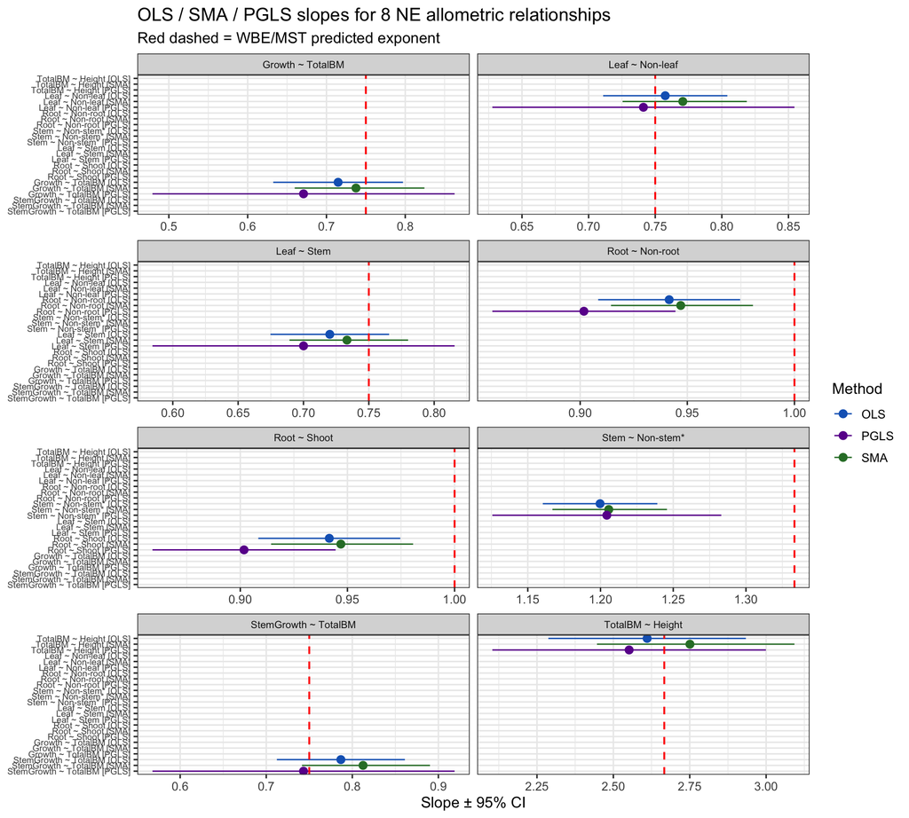

```r
# Forest plot: slopes by method and relationship
ne_forest_dat <- ne_results_all |>
  dplyr::filter(!is.na(slope), !is.na(ci_lower), !is.na(ci_upper)) |>
  dplyr::mutate(
    rel_method = paste0(relationship, " [", method, "]"),
    rel_method = factor(rel_method, levels = rev(unique(rel_method))))

wbe_refs_ne <- purrr::map_dfr(ne_rel_list, function(r)
  tibble::tibble(relationship = r$label, wbe_slope = r$wbe))

ggplot(ne_forest_dat, aes(slope, rel_method, colour = method)) +
  geom_pointrange(aes(xmin = ci_lower, xmax = ci_upper), size = 0.5) +
  geom_vline(data = ne_results_all |> dplyr::distinct(relationship, wbe_slope),
             aes(xintercept = wbe_slope), colour = "red",
             linetype = "dashed", linewidth = 0.7, inherit.aes = FALSE) +
  scale_colour_manual(values = c(OLS = "#1565C0", SMA = "#2E7D32", PGLS = "#6A1B9A")) +
  facet_wrap(~relationship, scales = "free_x", ncol = 2) +
  labs(title = "OLS / SMA / PGLS slopes for 8 NE allometric relationships",
       subtitle = "Red dashed = WBE/MST predicted exponent",
       x = "Slope ± 95% CI", y = NULL, colour = "Method") +
  theme(strip.text = element_text(size = 8), axis.text.y = element_text(size = 7))
```

## 8.6 Gymnosperm vs Angiosperm analysis

```r
ne_div_results <- purrr::map_dfr(
  c("Gymnosperm", "Angiosperm"),
  function(div) {
    df_div <- ne_sp_means |> dplyr::filter(ne_division == div)
    if (nrow(df_div) < 8) {
      message(sprintf("Division %s: only %d rows — skipping", div, nrow(df_div)))
      return(NULL)
    }
    # Use sub-tree for PGLS
    tree_div <- if (!is.null(ne_pgls_tree)) {
      tips_div <- df_div$sp_tree[df_div$sp_tree %in% ne_pgls_tree$tip.label]
      if (length(tips_div) >= 8) ape::keep.tip(ne_pgls_tree, tips_div) else NULL
    } else NULL

    purrr::map_dfr(ne_rel_list, function(r)
      run_one_allom(df_div, tree_div, r$y, r$x,
                    rel_label = r$label, wbe_slope = r$wbe,
                    group_label = div))
  })

# Division comparison table (OLS only for brevity, plus PGLS where available)
ne_div_ols <- ne_div_results |>
  dplyr::filter(method == "OLS") |>
  dplyr::select(relationship, group, n_species, slope, ci_lower, ci_upper, p_vs_wbe) |>
  dplyr::mutate(across(where(is.numeric), ~ round(., 3)))

kable(ne_div_ols,
      col.names = c("Relationship", "Division", "N spp", "OLS slope",
                    "CI lower", "CI upper", "p vs WBE"),
      caption = "Gymnosperm vs Angiosperm OLS slopes for 8 allometric relationships. WBE predicts identical slopes across divisions with differing intercepts.")
```

Gymnosperm vs Angiosperm OLS slopes for 8 allometric relationships. WBE predicts identical slopes across divisions with differing intercepts.

| Relationship | Division | N spp | OLS slope | CI lower | CI upper | p vs WBE |
| --- | --- | --- | --- | --- | --- | --- |
| TotalBM ~ Height | Gymnosperm | 16 | 2.611 | 2.195 | 3.028 | 0.780 |
| Leaf ~ Non-leaf | Gymnosperm | 18 | 0.809 | 0.727 | 0.891 | 0.147 |
| Root ~ Non-root | Gymnosperm | 18 | 0.987 | 0.942 | 1.033 | 0.562 |
| Stem ~ Non-stem* | Gymnosperm | 18 | 1.146 | 1.101 | 1.191 | 0.000 |
| Leaf ~ Stem | Gymnosperm | 18 | 0.789 | 0.710 | 0.867 | 0.314 |
| Root ~ Shoot | Gymnosperm | 18 | 0.987 | 0.942 | 1.033 | 0.562 |
| Growth ~ TotalBM | Gymnosperm | 11 | 0.785 | 0.670 | 0.901 | 0.506 |
| StemGrowth ~ TotalBM | Gymnosperm | 16 | 0.861 | 0.738 | 0.984 | 0.073 |
| TotalBM ~ Height | Angiosperm | 16 | 2.614 | 2.095 | 3.132 | 0.830 |
| Leaf ~ Non-leaf | Angiosperm | 22 | 0.717 | 0.674 | 0.759 | 0.119 |
| Root ~ Non-root | Angiosperm | 22 | 0.926 | 0.878 | 0.974 | 0.004 |
| Stem ~ Non-stem* | Angiosperm | 22 | 1.225 | 1.166 | 1.285 | 0.001 |
| Leaf ~ Stem | Angiosperm | 22 | 0.676 | 0.632 | 0.720 | 0.002 |
| Root ~ Shoot | Angiosperm | 22 | 0.926 | 0.878 | 0.974 | 0.004 |
| Growth ~ TotalBM | Angiosperm | 12 | 0.694 | 0.565 | 0.822 | 0.353 |
| StemGrowth ~ TotalBM | Angiosperm | 17 | 0.761 | 0.658 | 0.863 | 0.830 |

```r
# ANCOVA: test slope and intercept heterogeneity between divisions
ne_ancova_key <- purrr::map_dfr(ne_rel_list, function(r) {
  df_anc <- ne_sp_means |>
    dplyr::filter(!is.na(ne_division),
                  is.finite(.data[[r$y]]), is.finite(.data[[r$x]]))
  if (nrow(df_anc) < 15 || dplyr::n_distinct(df_anc$ne_division) < 2) return(NULL)

  m2 <- lm(as.formula(paste(r$y, "~", r$x, "* ne_division")), data = df_anc)
  m1 <- lm(as.formula(paste(r$y, "~", r$x, "+ ne_division")), data = df_anc)
  m0 <- lm(as.formula(paste(r$y, "~", r$x)),                  data = df_anc)

  f21 <- tryCatch(anova(m1, m2), error = function(e) NULL)
  f10 <- tryCatch(anova(m0, m1), error = function(e) NULL)

  tibble::tibble(
    relationship     = r$label,
    n_total          = nrow(df_anc),
    p_slope_hetero   = if (!is.null(f21)) f21$`Pr(>F)`[2] else NA_real_,
    p_intercept_diff = if (!is.null(f10)) f10$`Pr(>F)`[2] else NA_real_,
    angio_intercept_shift = tryCatch(
      coef(m1)[grep("ne_divisionGymnosperm|ne_divisionAngiosperm", names(coef(m1)))][1],
      error = function(e) NA_real_)
  )
})

kable(ne_ancova_tbl <- ne_ancova_key |>
        dplyr::mutate(
          slopes_homogeneous = dplyr::if_else(!is.na(p_slope_hetero),
                                              dplyr::if_else(p_slope_hetero > 0.05,
                                                             "Yes", "No"), "?"),
          intercept_different = dplyr::if_else(!is.na(p_intercept_diff),
                                               dplyr::if_else(p_intercept_diff < 0.05,
                                                              "Yes", "No"), "?"),
          across(c(p_slope_hetero, p_intercept_diff, angio_intercept_shift),
                 ~ round(., 4))) |>
        dplyr::select(relationship, n_total, p_slope_hetero, slopes_homogeneous,
                      p_intercept_diff, intercept_different, angio_intercept_shift),
      col.names = c("Relationship", "N", "p (slope hetero)", "Slopes equal?",
                    "p (intercept)", "Intercepts differ?", "Intercept shift"),
      caption = "ANCOVA tests for division (gymno vs angio): slope homogeneity (M2 vs M1) and intercept difference (M1 vs M0). WBE predicts slopes homogeneous, intercepts may differ due to hydraulic and LMA differences.")
```

ANCOVA tests for division (gymno vs angio): slope homogeneity (M2 vs M1) and intercept difference (M1 vs M0). WBE predicts slopes homogeneous, intercepts may differ due to hydraulic and LMA differences.

| Relationship | N | p (slope hetero) | Slopes equal? | p (intercept) | Intercepts differ? | Intercept shift |
| --- | --- | --- | --- | --- | --- | --- |
| TotalBM ~ Height | 32 | 0.9951 | Yes | 0.5989 | No | 0.0643 |
| Leaf ~ Non-leaf | 40 | 0.0329 | No | 0.0005 | Yes | 0.3154 |
| Root ~ Non-root | 40 | 0.0992 | Yes | 0.4622 | No | -0.0497 |
| Stem ~ Non-stem* | 40 | 0.0658 | Yes | 0.8065 | No | -0.0177 |
| Leaf ~ Stem | 40 | 0.0100 | No | 0.0019 | Yes | 0.2917 |
| Root ~ Shoot | 40 | 0.0992 | Yes | 0.4622 | No | -0.0497 |
| Growth ~ TotalBM | 23 | 0.2793 | Yes | 0.1897 | No | -0.2462 |
| StemGrowth ~ TotalBM | 33 | 0.2016 | Yes | 0.2445 | No | -0.1734 |

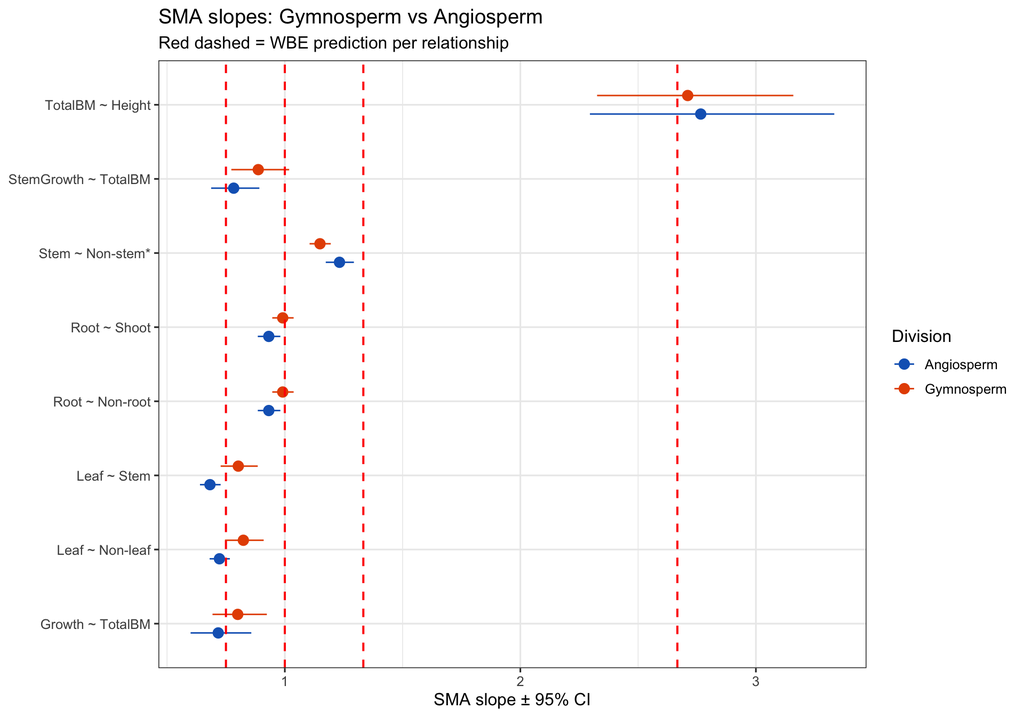

```r
# Forest plot: gymno vs angio slopes for key relationships
ne_div_sma <- ne_div_results |> dplyr::filter(method == "SMA", !is.na(slope))
if (nrow(ne_div_sma) > 0) {
  ggplot(ne_div_sma, aes(slope, relationship, colour = group)) +
    geom_pointrange(aes(xmin = ci_lower, xmax = ci_upper),
                    position = position_dodge(width = 0.5), size = 0.6) +
    geom_vline(data = wbe_refs_ne, aes(xintercept = wbe_slope),
               colour = "red", linetype = "dashed", linewidth = 0.7,
               inherit.aes = FALSE) +
    scale_colour_manual(values = c(Gymnosperm = "#E65100", Angiosperm = "#1565C0")) +
    labs(title = "SMA slopes: Gymnosperm vs Angiosperm",
         subtitle = "Red dashed = WBE prediction per relationship",
         x = "SMA slope ± 95% CI", y = NULL, colour = "Division")
}
```

## 8.7 Family-level analysis

```r
# Identify families with ≥5 species for OLS/SMA analysis
ne_fam_coverage <- ne_sp_means |>
  dplyr::filter(!is.na(ne_family)) |>
  dplyr::group_by(ne_family, ne_division) |>
  dplyr::summarise(
    n_species = dplyr::n(),
    n_with_leaf_stem = sum(!is.na(log_leaf_biomass_kg) & !is.na(log_stem_biomass_kg)),
    n_with_growth    = sum(!is.na(log_total_growth_kgyr) & !is.na(log_total_biomass_kg)),
    .groups = "drop") |>
  dplyr::filter(n_species >= 5) |>
  dplyr::arrange(dplyr::desc(n_species))

kable(ne_fam_coverage,
      caption = "Niklas-Enquist: families with ≥5 species in species-means table.")
```

Niklas-Enquist: families with ≥5 species in species-means table.

| ne_family | ne_division | n_species | n_with_leaf_stem | n_with_growth |
| --- | --- | --- | --- | --- |
| Pinaceae | Gymnosperm | 14 | 14 | 7 |
| Betulaceae | Angiosperm | 6 | 6 | 2 |
| Fagaceae | Angiosperm | 5 | 5 | 4 |

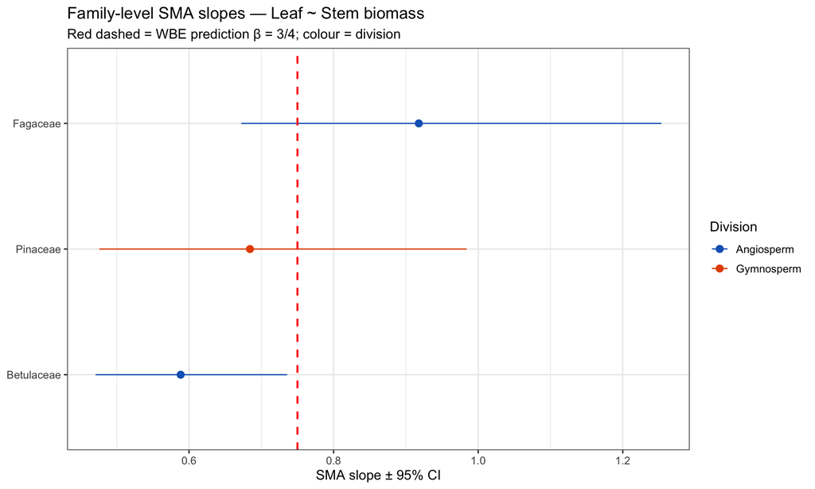

```r
# Family-level OLS and SMA for Leaf ~ Stem (key WBE prediction: β = 3/4)
ne_fam_ls <- purrr::map_dfr(ne_fam_coverage$ne_family, function(fam) {
  df_f <- ne_sp_means |>
    dplyr::filter(ne_family == fam,
                  is.finite(log_leaf_biomass_kg),
                  is.finite(log_stem_biomass_kg))
  n_f <- nrow(df_f)
  if (n_f < 5) return(NULL)
  ols_f <- lm(log_leaf_biomass_kg ~ log_stem_biomass_kg, data = df_f)
  sma_f <- tryCatch(smatr::sma(log_leaf_biomass_kg ~ log_stem_biomass_kg,
                                data = df_f), error = function(e) NULL)
  ci_o  <- tryCatch(confint(ols_f)[2, ], error = function(e) c(NA, NA))
  tibble::tibble(
    family       = fam,
    division     = unique(df_f$ne_division[!is.na(df_f$ne_division)])[1],
    n_species    = n_f,
    ols_slope    = coef(ols_f)[2],
    ols_se       = summary(ols_f)$coefficients[2, 2],
    ols_intercept = coef(ols_f)[1],
    ols_cilo     = ci_o[1], ols_cihi = ci_o[2],
    sma_slope    = if (!is.null(sma_f)) sma_f$coef[[1]][2, 1] else NA_real_,
    sma_cilo     = if (!is.null(sma_f)) sma_f$coef[[1]][2, 2] else NA_real_,
    sma_cihi     = if (!is.null(sma_f)) sma_f$coef[[1]][2, 3] else NA_real_
  )
})

if (nrow(ne_fam_ls) > 0) {
  kable(ne_fam_ls |> dplyr::mutate(across(where(is.numeric), ~ round(., 3))),
        caption = "Family-level OLS and SMA slopes for Leaf ~ Stem (WBE β = 3/4). Families with ≥5 species.")

  # Forest plot: SMA slopes per family
  ne_fam_ls |>
    dplyr::filter(!is.na(sma_slope)) |>
    dplyr::mutate(family = reorder(family, sma_slope)) |>
    ggplot(aes(sma_slope, family, colour = division)) +
    geom_pointrange(aes(xmin = sma_cilo, xmax = sma_cihi), size = 0.5) +
    geom_vline(xintercept = 3/4, colour = "red", linetype = "dashed", linewidth = 0.8) +
    scale_colour_manual(values = c(Gymnosperm = "#E65100", Angiosperm = "#1565C0"),
                        na.value = "grey50") +
    labs(title = "Family-level SMA slopes — Leaf ~ Stem biomass",
         subtitle = "Red dashed = WBE prediction β = 3/4; colour = division",
         x = "SMA slope ± 95% CI", y = NULL, colour = "Division")
}
```

```r
# Within-family PGLS where N ≥ 15 species in NE tree
ne_fam_pgls_fits <- NULL
if (!is.null(ne_pgls_tree)) {
  fam_pgls_eligible <- ne_fam_coverage |>
    dplyr::filter(n_with_leaf_stem >= 15) |>
    dplyr::pull(ne_family)

  ne_fam_pgls_fits <- purrr::map_dfr(fam_pgls_eligible, function(fam) {
    df_f <- ne_sp_means |>
      dplyr::filter(ne_family == fam,
                    sp_tree %in% ne_pgls_tree$tip.label,
                    is.finite(log_leaf_biomass_kg),
                    is.finite(log_stem_biomass_kg))
    if (nrow(df_f) < 10) return(NULL)
    tr_f <- ape::keep.tip(ne_pgls_tree, df_f$sp_tree)
    tr_f$node.label <- NULL
    df_fp <- as.data.frame(df_f); rownames(df_fp) <- df_fp$sp_tree
    cd_f  <- tryCatch(
      caper::comparative.data(phy = tr_f, data = df_fp, names.col = "sp_tree",
                               vcv = TRUE, warn.dropped = FALSE),
      error = function(e) NULL)
    if (is.null(cd_f)) return(NULL)
    pg_f <- tryCatch(
      caper::pgls(log_leaf_biomass_kg ~ log_stem_biomass_kg, data = cd_f,
                  lambda = "ML", bounds = list(lambda = c(1e-6, 1))),
      error = function(e) NULL)
    if (is.null(pg_f)) return(NULL)
    pg_s <- summary(pg_f)
    sl <- coef(pg_f)[2]; se <- coef(pg_s)[2, 2]
    tibble::tibble(
      family = fam, n_species = nrow(df_f),
      pgls_slope = sl, pgls_se = se,
      pgls_cilo  = sl - 1.96 * se, pgls_cihi = sl + 1.96 * se,
      pgls_lambda = tryCatch(pg_f$param["lambda"], error = function(e) NA_real_),
      pgls_r2 = pg_s$r.squared)
  })

  if (!is.null(ne_fam_pgls_fits) && nrow(ne_fam_pgls_fits) > 0) {
    kable(ne_fam_pgls_fits |> dplyr::mutate(across(where(is.numeric), ~ round(., 3))),
          caption = "Within-family PGLS slopes — Leaf ~ Stem (families with ≥15 matched species). WBE β = 3/4.")
  } else {
    message("Within-family PGLS: no families met ≥15 species threshold in tree.")
  }
}
```

```
## Slope heterogeneity (Leaf ~ Stem, family level): I² = 80.9%, τ² = 0.0286, Q(2) = 10.48
## High I² (>50%): allometric exponents vary substantially across plant families beyond sampling error.
## Intercept heterogeneity (Leaf ~ Stem, family level): I² = 96.9%, Q(2) = 65.06
```

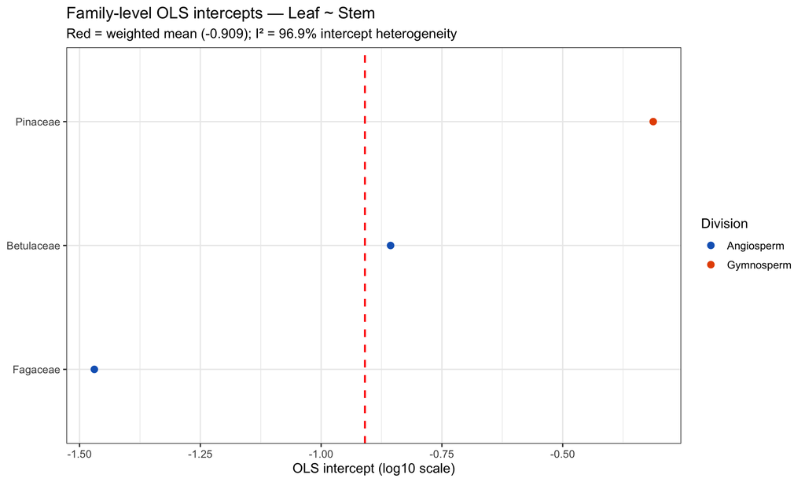

```r
# Meta-analytic heterogeneity in family slopes (Leaf ~ Stem)
if (nrow(ne_fam_ls) >= 3) {
  w_fam    <- 1 / ne_fam_ls$ols_se^2
  wm_fam   <- weighted.mean(ne_fam_ls$ols_slope, w_fam, na.rm = TRUE)
  Q_fam    <- sum(w_fam * (ne_fam_ls$ols_slope - wm_fam)^2, na.rm = TRUE)
  df_fam   <- sum(!is.na(ne_fam_ls$ols_slope)) - 1
  I2_fam   <- max(0, (Q_fam - df_fam) / Q_fam * 100)
  tau2_fam <- max(0, (Q_fam - df_fam) / (sum(w_fam) - sum(w_fam^2) / sum(w_fam)))

  if (HAS_METAFOR) {
    rma_fam_slope <- tryCatch(
      metafor::rma(yi = ne_fam_ls$ols_slope, sei = ne_fam_ls$ols_se, method = "REML"),
      error = function(e) NULL)
    if (!is.null(rma_fam_slope)) {
      I2_fam   <- rma_fam_slope$I2
      tau2_fam <- rma_fam_slope$tau2
    }
  }

  cat(sprintf("Slope heterogeneity (Leaf ~ Stem, family level): I² = %.1f%%, τ² = %.4f, Q(%d) = %.2f\n",
              I2_fam, tau2_fam, df_fam, Q_fam))
  if (I2_fam > 50)
    cat("High I² (>50%): allometric exponents vary substantially across plant families beyond sampling error.\n")
  else
    cat("Low I² (≤50%): slope variation is consistent with sampling error — exponent is relatively conserved across families.\n")

  # Intercept heterogeneity
  w_int  <- 1 / ne_fam_ls$ols_se^2  # approximate weight using slope SE
  wm_int <- weighted.mean(ne_fam_ls$ols_intercept, w_int, na.rm = TRUE)
  Q_int  <- sum(w_int * (ne_fam_ls$ols_intercept - wm_int)^2, na.rm = TRUE)
  df_int <- sum(!is.na(ne_fam_ls$ols_intercept)) - 1
  I2_int <- max(0, (Q_int - df_int) / Q_int * 100)
  cat(sprintf("Intercept heterogeneity (Leaf ~ Stem, family level): I² = %.1f%%, Q(%d) = %.2f\n",
              I2_int, df_int, Q_int))

  # Intercept forest plot
  ne_fam_ls |>
    dplyr::filter(!is.na(ols_intercept)) |>
    dplyr::mutate(family = reorder(family, ols_intercept)) |>
    ggplot(aes(ols_intercept, family, colour = division)) +
    geom_point(size = 2.5) +
    geom_vline(xintercept = wm_int, colour = "red", linetype = "dashed",
               linewidth = 0.8) +
    scale_colour_manual(values = c(Gymnosperm = "#E65100", Angiosperm = "#1565C0"),
                        na.value = "grey50") +
    labs(title = "Family-level OLS intercepts — Leaf ~ Stem",
         subtitle = sprintf("Red = weighted mean (%.3f); I² = %.1f%% intercept heterogeneity",
                            wm_int, I2_int),
         x = "OLS intercept (log10 scale)", y = NULL, colour = "Division")
}
```

## 8.8 Intraspecific organ-level scaling (BAAD)

> ⚠️ **Data note:** The Niklas-Enquist dataset contains predominantly one record per taxon (species-level literature compilation). Intraspecific (ontogenetic) organ-level scaling requires individual-level data. BAAD (Falster et al. 2015, *Ecology* 96:1445) provides individual-level measurements of leaf, stem, root, and total biomass, enabling genuine intraspecific allometry.

```r
if (HAS_BAAD && exists("baad_raw") && !is.null(baad_raw)) {
  # Extract BAAD organ-level data with species
  baad_organs <- baad_raw |>
    dplyr::filter(!is.na(m.lf), m.lf > 0,
                  !is.na(m.st), m.st > 0,
                  !is.na(speciesMatched)) |>
    dplyr::mutate(
      log_leaf  = log10(m.lf),
      log_stem  = log10(m.st),
      log_total = log10(m.to + 1e-9),
      log_root  = if ("m.rt" %in% names(baad_raw)) log10(pmax(m.rt, 1e-9)) else NA_real_,
      species   = speciesMatched)

  # Intraspecific criteria: ≥10 records, >2 orders of magnitude in stem mass
  intra_organ_sp <- baad_organs |>
    dplyr::group_by(species) |>
    dplyr::filter(
      dplyr::n() >= 10,
      log10(max(m.st, na.rm = TRUE) / pmax(min(m.st, na.rm = TRUE), 1e-9)) >= 2) |>
    dplyr::ungroup() |>
    dplyr::pull(species) |>
    unique()

  cat(sprintf("BAAD: %d species meet intraspecific criteria (n≥10, >2 OOM in stem mass)\n",
              length(intra_organ_sp)))

  intra_ls <- purrr::map_dfr(intra_organ_sp, function(sp) {
    df_sp <- baad_organs |>
      dplyr::filter(species == sp, is.finite(log_leaf), is.finite(log_stem))
    if (nrow(df_sp) < 10) return(NULL)
    ols_sp <- lm(log_leaf ~ log_stem, data = df_sp)
    ci_sp  <- tryCatch(confint(ols_sp)[2, ], error = function(e) c(NA, NA))
    tibble::tibble(
      species  = sp,
      n        = nrow(df_sp),
      slope    = coef(ols_sp)[2],
      ci_lower = ci_sp[1], ci_upper = ci_sp[2],
      r2       = summary(ols_sp)$r.squared,
      intercept = coef(ols_sp)[1]
    )
  })

  if (nrow(intra_ls) > 0) {
    t_intra_ls <- t.test(intra_ls$slope, mu = 3/4)
    cat(sprintf(
      "Intraspecific Leaf~Stem (BAAD): mean β = %.3f ± %.3f SD; t-test vs 3/4: t = %.3f, p = %.4f\n",
      mean(intra_ls$slope, na.rm = TRUE),
      sd(intra_ls$slope,   na.rm = TRUE),
      t_intra_ls$statistic, t_intra_ls$p.value))

    # Compare intraspecific mean vs interspecific (NE pooled)
    ne_inter_ls <- ne_results_all |>
      dplyr::filter(relationship == "Leaf ~ Stem", method == "OLS")
    if (nrow(ne_inter_ls) > 0)
      cat(sprintf("Interspecific Leaf~Stem (NE pooled OLS): β = %.3f\n",
                  ne_inter_ls$slope[1]))

    kable(intra_ls |> dplyr::arrange(dplyr::desc(n)) |> head(20) |>
            dplyr::mutate(across(where(is.numeric), ~ round(., 3))),
          caption = "Top 20 species by N: intraspecific Leaf ~ Stem slopes (BAAD).")

    ggplot(intra_ls, aes(slope)) +
      geom_histogram(bins = 30, fill = "#66BB6A", colour = "white") +
      geom_vline(xintercept = 3/4, colour = "red", linetype = "dashed",
                 linewidth = 1) +
      geom_vline(xintercept = mean(intra_ls$slope, na.rm = TRUE),
                 colour = "black", linewidth = 1) +
      labs(title = paste0("Intraspecific Leaf ~ Stem slopes (N = ",
                          nrow(intra_ls), " BAAD species)"),
           subtitle = "Red dashed = WBE 3/4; Black = observed mean",
           x = "OLS slope (intraspecific)", y = "Count")

    # Intercept heterogeneity across species
    I2_intra <- {
      se_intra <- (intra_ls$ci_upper - intra_ls$ci_lower) / (2 * 1.96)
      w_i      <- 1 / se_intra^2
      wm_i     <- weighted.mean(intra_ls$slope, w_i, na.rm = TRUE)
      Q_i      <- sum(w_i * (intra_ls$slope - wm_i)^2, na.rm = TRUE)
      df_i     <- sum(!is.na(intra_ls$slope)) - 1
      max(0, (Q_i - df_i) / Q_i * 100)
    }
    cat(sprintf("Intraspecific slope heterogeneity (Leaf~Stem, species level): I² = %.1f%%\n",
                I2_intra))
  } else {
    message("No BAAD species met intraspecific criteria for Leaf ~ Stem.")
  }
} else {
  message("BAAD not available — intraspecific organ-level scaling skipped.")
}
```

```
## BAAD: 141 species meet intraspecific criteria (n≥10, >2 OOM in stem mass)
## Intraspecific Leaf~Stem (BAAD): mean β = 0.750 ± 0.165 SD; t-test vs 3/4: t = 0.004, p = 0.9965
## Interspecific Leaf~Stem (NE pooled OLS): β = 0.720
## Intraspecific slope heterogeneity (Leaf~Stem, species level): I² = 95.4%
```

## 8.9 Comprehensive WBE scorecard (Niklas-Enquist)

```r
# Compile scorecard from the 8-relationship results
ne_scorecard <- ne_results_all |>
  dplyr::filter(!is.na(slope), !is.na(ci_lower), !is.na(ci_upper)) |>
  dplyr::mutate(
    wbe_in_ci = (ci_lower <= wbe_slope) & (wbe_slope <= ci_upper),
    verdict   = dplyr::case_when(
      is.na(wbe_slope)  ~ "No prediction",
      is.na(wbe_in_ci)  ~ "Insufficient data",
      wbe_in_ci         ~ "SUPPORTED",
      TRUE              ~ "NOT SUPPORTED")
  ) |>
  dplyr::select(relationship, method, wbe_slope, n_species,
                slope, ci_lower, ci_upper, r_squared, lambda_ml, p_vs_wbe, verdict) |>
  dplyr::mutate(across(where(is.numeric) & !dplyr::any_of("n_species"),
                       ~ round(., 3)))

kable(ne_scorecard |>
        dplyr::select(relationship, method, wbe_slope, n_species,
                      slope, ci_lower, ci_upper, r_squared, lambda_ml, verdict),
      col.names = c("Relationship", "Method", "WBE β", "N spp",
                    "Slope", "CI lo", "CI hi", "R²", "λ (PGLS)", "Verdict"),
      caption = "Comprehensive WBE scorecard (Niklas-Enquist). SUPPORTED = WBE predicted exponent lies within 95% CI. * Stem ~ Non-stem WBE β is UNVERIFIED derivation.")
```

Comprehensive WBE scorecard (Niklas-Enquist). SUPPORTED = WBE predicted exponent lies within 95% CI. * Stem ~ Non-stem WBE β is UNVERIFIED derivation.

| Relationship | Method | WBE β | N spp | Slope | CI lo | CI hi | R² | λ (PGLS) | Verdict |
| --- | --- | --- | --- | --- | --- | --- | --- | --- | --- |
| TotalBM ~ Height | OLS | 2.667 | 32 | 2.611 | 2.287 | 2.934 | 0.901 | NA | SUPPORTED |
| TotalBM ~ Height | SMA | 2.667 | 32 | 2.751 | 2.446 | 3.093 | 0.901 | NA | SUPPORTED |
| TotalBM ~ Height | PGLS | 2.667 | 32 | 2.552 | 2.104 | 2.999 | 0.886 | 0.000 | SUPPORTED |
| Leaf ~ Non-leaf | OLS | 0.750 | 40 | 0.758 | 0.711 | 0.804 | 0.966 | NA | SUPPORTED |
| Leaf ~ Non-leaf | SMA | 0.750 | 40 | 0.771 | 0.725 | 0.819 | 0.966 | NA | SUPPORTED |
| Leaf ~ Non-leaf | PGLS | 0.750 | 40 | 0.741 | 0.628 | 0.855 | 0.911 | 0.467 | SUPPORTED |
| Root ~ Non-root | OLS | 1.000 | 40 | 0.942 | 0.908 | 0.975 | 0.989 | NA | NOT SUPPORTED |
| Root ~ Non-root | SMA | 1.000 | 40 | 0.947 | 0.914 | 0.981 | 0.989 | NA | NOT SUPPORTED |
| Root ~ Non-root | PGLS | 1.000 | 40 | 0.902 | 0.859 | 0.944 | 0.991 | 0.000 | NOT SUPPORTED |
| Stem ~ Non-stem* | OLS | 1.333 | 40 | 1.200 | 1.160 | 1.239 | 0.990 | NA | NOT SUPPORTED |
| Stem ~ Non-stem* | SMA | 1.333 | 40 | 1.206 | 1.167 | 1.246 | 0.990 | NA | NOT SUPPORTED |
| Stem ~ Non-stem* | PGLS | 1.333 | 40 | 1.204 | 1.126 | 1.283 | 0.983 | 0.000 | NOT SUPPORTED |
| Leaf ~ Stem | OLS | 0.750 | 40 | 0.720 | 0.675 | 0.766 | 0.964 | NA | SUPPORTED |
| Leaf ~ Stem | SMA | 0.750 | 40 | 0.733 | 0.689 | 0.780 | 0.964 | NA | SUPPORTED |
| Leaf ~ Stem | PGLS | 0.750 | 40 | 0.700 | 0.584 | 0.816 | 0.898 | 0.416 | SUPPORTED |
| Root ~ Shoot | OLS | 1.000 | 40 | 0.942 | 0.908 | 0.975 | 0.989 | NA | NOT SUPPORTED |
| Root ~ Shoot | SMA | 1.000 | 40 | 0.947 | 0.914 | 0.981 | 0.989 | NA | NOT SUPPORTED |
| Root ~ Shoot | PGLS | 1.000 | 40 | 0.902 | 0.859 | 0.944 | 0.991 | 0.000 | NOT SUPPORTED |
| Growth ~ TotalBM | OLS | 0.750 | 23 | 0.715 | 0.632 | 0.797 | 0.940 | NA | SUPPORTED |
| Growth ~ TotalBM | SMA | 0.750 | 23 | 0.737 | 0.660 | 0.824 | 0.940 | NA | SUPPORTED |
| Growth ~ TotalBM | PGLS | 0.750 | 23 | 0.671 | 0.479 | 0.863 | 0.746 | 0.000 | SUPPORTED |
| StemGrowth ~ TotalBM | OLS | 0.750 | 33 | 0.787 | 0.712 | 0.861 | 0.938 | NA | SUPPORTED |
| StemGrowth ~ TotalBM | SMA | 0.750 | 33 | 0.812 | 0.742 | 0.890 | 0.938 | NA | SUPPORTED |
| StemGrowth ~ TotalBM | PGLS | 0.750 | 33 | 0.743 | 0.568 | 0.919 | 0.812 | 0.007 | SUPPORTED |

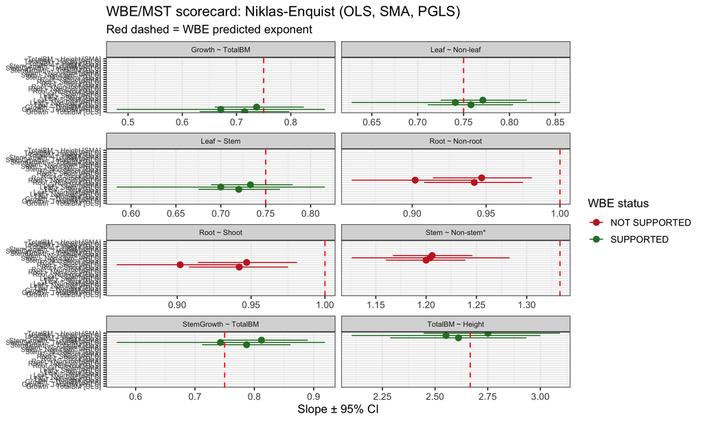

```r
# Scorecard plot
ne_scorecard |>
  dplyr::filter(!is.na(slope)) |>
  ggplot(aes(slope, paste0(relationship, " [", method, "]"),
             colour = verdict)) +
  geom_pointrange(aes(xmin = ci_lower, xmax = ci_upper), size = 0.5) +
  geom_vline(data = ne_scorecard |> dplyr::distinct(relationship, wbe_slope),
             aes(xintercept = wbe_slope),
             colour = "red", linetype = "dashed", linewidth = 0.6,
             inherit.aes = FALSE) +
  scale_colour_manual(
    values = c("SUPPORTED"         = "#2E7D32",
               "NOT SUPPORTED"     = "#C62828",
               "Insufficient data" = "grey50",
               "No prediction"     = "grey80")) +
  facet_wrap(~relationship, scales = "free_x", ncol = 2) +
  labs(title = "WBE/MST scorecard: Niklas-Enquist (OLS, SMA, PGLS)",
       subtitle = "Red dashed = WBE predicted exponent",
       x = "Slope ± 95% CI", y = NULL, colour = "WBE status") +
  theme(strip.text = element_text(size = 7.5),
        axis.text.y = element_text(size = 7))
```

# 9 Intraspecific Scaling Synthesis

> ⚠️ **Intra- vs interspecific scaling:** Intraspecific and interspecific scaling exponents often differ (Glazier 2005, *Biol. Rev.*). Intraspecific slopes reflect ontogenetic changes within individual growth trajectories; interspecific slopes reflect evolutionary diversification of body plan. Neither is the ‘correct’ test of WBE theory — each addresses a different biological question.

```r
intra_all <- bind_rows(
  if (exists("intra_hd") && nrow(intra_hd) > 0)
    intra_hd |> mutate(relationship = "H ~ DBH") else NULL,
  if (exists("intra_agb") && nrow(intra_agb) > 0)
    intra_agb |> mutate(relationship = "AGB ~ DBH") else NULL)

if (!is.null(intra_all) && nrow(intra_all) > 0) {
  inter_beta <- c(
    "H ~ DBH"   = if (!is.null(sma_hd)) as.numeric(coef(sma_hd)[[1]]["slope"]) else WBE_H_DBH,
    "AGB ~ DBH" = if (exists("sma_agb") && !is.null(sma_agb)) as.numeric(coef(sma_agb)[[1]]["slope"]) else WBE_AGB_DBH)

  ref_lines <- tibble(
    relationship = c("H ~ DBH","H ~ DBH","AGB ~ DBH","AGB ~ DBH"),
    xintercept   = c(WBE_H_DBH, inter_beta["H ~ DBH"],
                     WBE_AGB_DBH, inter_beta["AGB ~ DBH"]),
    label        = c("WBE (inter)","SMA inter","WBE (inter)","SMA inter"))

  ggplot(intra_all, aes(slope, fill = relationship)) +
    geom_density(alpha = 0.5) +
    geom_vline(data = ref_lines, aes(xintercept = xintercept, linetype = label),
               colour = "red", linewidth = 0.8) +
    facet_wrap(~relationship, scales = "free") +
    labs(title = "Intraspecific β distribution vs interspecific reference",
         x = "OLS slope (intraspecific)", y = "Density",
         linetype = "Reference") +
    theme(legend.position = "bottom")

  glazier_table <- intra_all |>
    group_by(relationship) |>
    summarise(
      Intraspecific_median = median(slope, na.rm = TRUE),
      Intraspecific_SD     = sd(slope, na.rm = TRUE),
      N_species            = n(),
      pct_below_WBE        = mean(slope < inter_beta[relationship[1]], na.rm = TRUE) * 100,
      .groups = "drop") |>
    mutate(Interspecific_SMA = inter_beta[relationship])

  kable(glazier_table, digits = 3,
        caption = "Glazier-style comparison: interspecific vs intraspecific β.")
}
```

Glazier-style comparison: interspecific vs intraspecific β.

| relationship | Intraspecific_median | Intraspecific_SD | N_species | pct_below_WBE | Interspecific_SMA |
| --- | --- | --- | --- | --- | --- |
| AGB ~ DBH | 2.065 | 0.547 | 6 | NaN | NA |
| H ~ DBH | 0.623 | 0.124 | 537 | NaN | NA |

# 10 Phylogenetic Analyses

## 10.1 Phylogeny construction

```r
spp_pool <- allom |>
  filter(!is.na(DBH_cm), !is.na(Height_m), DBH_cm > 0, Height_m > 0,
         !is.na(species), !grepl("sp\\.?$|cf\\.", species)) |>
  mutate(log_dbh = log10(DBH_cm), log_h = log10(Height_m),
         # AGB species means: exclude Chojnacky-derived NEON values (partly circular with DBH)
         log_agb = ifelse(!is.na(AGB_kg) & AGB_kg > 0 & agb_eligible, log10(AGB_kg), NA_real_)) |>
  group_by(species, family) |>
  summarise(log_dbh_m = mean(log_dbh, na.rm = TRUE),
            log_h_m   = mean(log_h, na.rm = TRUE),
            log_agb_m = mean(log_agb, na.rm = TRUE),
            n = n(), .groups = "drop") |>
  filter(n >= 5) |>  # n >= 5 for reliable species means in PGLS
  mutate(sp_tree = gsub(" ", "_", species),
         genus   = word(species, 1)) |>
  distinct(sp_tree, .keep_all = TRUE)

if (HAS_PHYLOMAKER && nrow(spp_pool) > 20) {
  # Cap to 600 species for tractable phylogeny; prefer higher-n species
  spp_pool_phy <- spp_pool |>
    filter(!is.na(family)) |>
    arrange(desc(n)) |>
    slice_head(n = 600)

  sp_list_phy <- spp_pool_phy |>
    distinct(sp_tree, genus, family)

  phy_grand <- tryCatch({
    res <- V.PhyloMaker2::phylo.maker(
      sp.list = data.frame(species = sp_list_phy$sp_tree,
                           genus   = sp_list_phy$genus,
                           family  = sp_list_phy$family),
      tree      = V.PhyloMaker2::GBOTB.extended.WP,
      nodes     = V.PhyloMaker2::nodes.info.1.WP,
      scenarios = "S3")
    res$scenario.3
  }, error = function(e) {
    message("V.PhyloMaker2 failed — PGLS skipped (no valid phylogeny available).")
    NULL
  })

  if (!is.null(phy_grand)) {
    set.seed(42)
    phy_grand <- multi2di(phy_grand, random = TRUE)
    phy_grand <- phytools::force.ultrametric(phy_grand, method = "extend")
    phy_grand$node.label <- NULL

    n_matched <- sum(spp_pool_phy$sp_tree %in% phy_grand$tip.label)
    cat(sprintf("Phylogeny: %d tips; %d/%d species matched.\n",
                length(phy_grand$tip.label), n_matched, nrow(spp_pool_phy)))
  } else {
    phy_grand <- NULL
  }
} else {
  message("V.PhyloMaker2 not available or insufficient species. Phylo sections skipped.")
  phy_grand <- NULL
}
```

[output not shown]

## 10.2 Phylogenetic signal

```r
if (!is.null(phy_grand)) {
  sig_df <- spp_pool_phy |>
    filter(sp_tree %in% phy_grand$tip.label) |>
    as.data.frame()

  compute_signal <- function(trait_vec, sp_names, tree, trait_name) {
    vals <- setNames(trait_vec, sp_names)
    vals <- vals[!is.na(vals)]
    pruned <- ape::drop.tip(tree, setdiff(tree$tip.label, names(vals)))
    if (length(pruned$tip.label) < 5) return(NULL)
    vals   <- vals[pruned$tip.label]
    lam <- tryCatch(phytools::phylosig(pruned, vals, method = "lambda", test = TRUE),
                    error = function(e) list(lambda = NA_real_, P = NA_real_))
    K   <- tryCatch(phytools::phylosig(pruned, vals, method = "K", test = TRUE),
                    error = function(e) list(K = NA_real_, P = NA_real_))
    # phylosig may return a bare numeric when test=FALSE or tree is degenerate
    lam_val <- if (is.list(lam)) lam$lambda else as.numeric(lam)[1]
    lam_p   <- if (is.list(lam) && !is.null(lam$P)) lam$P else NA_real_
    K_val   <- if (is.list(K)) K$K else as.numeric(K)[1]
    K_p     <- if (is.list(K) && !is.null(K$P)) K$P else NA_real_
    tibble(Trait = trait_name, N = length(vals),
           lambda = lam_val, p_lambda = lam_p,
           K = K_val, p_K = K_p)
  }

  sig_table <- bind_rows(
    compute_signal(sig_df$log_h_m,   sig_df$sp_tree, phy_grand, "log10(Height)"),
    compute_signal(sig_df$log_dbh_m, sig_df$sp_tree, phy_grand, "log10(DBH)"),
    compute_signal(sig_df$log_agb_m, sig_df$sp_tree, phy_grand, "log10(AGB)"))

  kable(sig_table, digits = 3,
        caption = "Phylogenetic signal: Pagel's λ and Blomberg's K.")
  cat("High λ for height indicates OLS will underestimate SEs for H~DBH. PGLS provides more conservative slope estimates under phylogenetic signal.\n")
}
```

[output not shown]

## 10.3 PGLS H ~ DBH (cross-dataset means)

```r
if (!is.null(phy_grand)) {
  pgls_df_grand <- spp_pool_phy |>
    filter(sp_tree %in% phy_grand$tip.label,
           !is.na(log_dbh_m), !is.na(log_h_m)) |>
    distinct(sp_tree, .keep_all = TRUE) |>
    as.data.frame()
  rownames(pgls_df_grand) <- pgls_df_grand$sp_tree

  cd_grand <- tryCatch(
    caper::comparative.data(phy = phy_grand, data = pgls_df_grand,
                            names.col = "sp_tree", vcv = TRUE),
    error = function(e) NULL)

  if (!is.null(cd_grand)) {
    pgls_hd_grand <- tryCatch(
      caper::pgls(log_h_m ~ log_dbh_m, data = cd_grand,
                  lambda = "ML", bounds = list(lambda = c(1e-6, 1))),
      error = function(e) NULL)

    if (!is.null(pgls_hd_grand)) {
      pg_sl  <- coef(pgls_hd_grand)["log_dbh_m"]
      pg_se  <- sqrt(diag(pgls_hd_grand$VCV))["log_dbh_m"]
      pg_ci  <- pg_sl + c(-1, 1) * qt(0.975, length(pgls_hd_grand$residuals) - 2) * pg_se
      pg_lam <- pgls_hd_grand$param["lambda"]

      lp_h <- tryCatch(pgls.profile(pgls_hd_grand, which = "lambda"),
                       error = function(e) NULL)
      lam_ci_h <- if (!is.null(lp_h))
        tryCatch(pgls.confint(lp_h)$ci.val, error = function(e) c(NA, NA))
      else c(NA, NA)

      ols_g <- lm(log_h_m ~ log_dbh_m, data = pgls_df_grand)
      sma_g <- tryCatch(sma(log_h_m ~ log_dbh_m, data = pgls_df_grand),
                         error = function(e) NULL)

      res_grand <- tibble(
        Method = c("OLS","SMA","PGLS"),
        Slope  = c(coef(ols_g)["log_dbh_m"],
                   if (!is.null(sma_g)) as.numeric(coef(sma_g)[[1]]["slope"]) else NA_real_,
                   pg_sl),
        CI_lo  = c(confint(ols_g,"log_dbh_m")[1],
                   if (!is.null(sma_g)) as.numeric(sma_g$slopetest[[1]]$test["lower"]) else NA_real_,
                   pg_ci[1]),
        CI_hi  = c(confint(ols_g,"log_dbh_m")[2],
                   if (!is.null(sma_g)) as.numeric(sma_g$slopetest[[1]]$test["upper"]) else NA_real_,
                   pg_ci[2]),
        Lambda  = c(NA, NA, pg_lam),
        Lam_CI  = c(NA, NA, paste0("[", round(lam_ci_h[1],3), ", ",
                                   round(lam_ci_h[2],3), "]")),
        R2      = c(summary(ols_g)$r.squared, NA_real_,
                    summary(pgls_hd_grand)$r.squared))

      kable(res_grand, digits = 3,
            caption = paste0("H ~ DBH: OLS / SMA / PGLS (N spp = ",
                             nrow(pgls_df_grand), "). WBE β = 2/3."))

      res_grand |>
        filter(!is.na(CI_lo)) |>
        ggplot(aes(Slope, Method)) +
        geom_pointrange(aes(xmin = CI_lo, xmax = CI_hi), size = 0.8) +
        geom_vline(xintercept = WBE_H_DBH, colour = "red",
                   linetype = "dashed", linewidth = 0.8) +
        labs(title = "H ~ DBH: OLS / SMA / PGLS comparison",
             subtitle = "Red = WBE 2/3", x = "Slope ± 95% CI", y = NULL)
    }
  }
}
```

## 10.4 PGLS AGB ~ DBH

```r
if (!is.null(phy_grand) && HAS_BAAD && nrow(pool_agb_primary) > 20) {
  pgls_df_agb <- spp_pool |>
    filter(sp_tree %in% phy_grand$tip.label, !is.na(log_agb_m)) |>
    distinct(sp_tree, .keep_all = TRUE) |>
    as.data.frame()
  rownames(pgls_df_agb) <- pgls_df_agb$sp_tree

  if (nrow(pgls_df_agb) > 10) {
    cd_agb <- tryCatch(
      caper::comparative.data(phy = phy_grand, data = pgls_df_agb,
                              names.col = "sp_tree", vcv = TRUE),
      error = function(e) NULL)

    if (!is.null(cd_agb)) {
      pgls_agb_g <- tryCatch(
        caper::pgls(log_agb_m ~ log_dbh_m, data = cd_agb,
                    lambda = "ML", bounds = list(lambda = c(1e-6, 1))),
        error = function(e) NULL)

      if (!is.null(pgls_agb_g)) {
        ag_sl <- coef(pgls_agb_g)["log_dbh_m"]
        ag_se <- sqrt(diag(pgls_agb_g$VCV))["log_dbh_m"]
        ag_ci <- ag_sl + c(-1, 1) * qt(0.975, length(pgls_agb_g$residuals) - 2) * ag_se
        cat(sprintf("PGLS AGB~DBH: slope = %.3f [%.3f, %.3f], λ = %.3f\n",
                    ag_sl, ag_ci[1], ag_ci[2], pgls_agb_g$param["lambda"]))
      }
    }
  }
}
```

## 10.5 Family-level PGLS

```r
if (!is.null(phy_grand)) {
  pgls_elig_fams <- fam_audit |> filter(pgls_eligible) |> pull(family)

  fam_pgls_fits <- map_df(pgls_elig_fams, function(fam) {
    d <- spp_pool |>
      filter(family == fam, sp_tree %in% phy_grand$tip.label,
             !is.na(log_h_m), !is.na(log_dbh_m))
    if (nrow(d) < 8) return(NULL)
    pruned <- tryCatch(
      ape::drop.tip(phy_grand, setdiff(phy_grand$tip.label, d$sp_tree)),
      error = function(e) NULL)
    if (is.null(pruned)) return(NULL)
    df_f <- d |> distinct(sp_tree, .keep_all = TRUE) |> as.data.frame()
    rownames(df_f) <- df_f$sp_tree
    cd_f <- tryCatch(
      caper::comparative.data(phy = pruned, data = df_f,
                              names.col = "sp_tree", vcv = TRUE),
      error = function(e) NULL)
    if (is.null(cd_f)) return(NULL)
    pg_f <- tryCatch(
      caper::pgls(log_h_m ~ log_dbh_m, data = cd_f,
                  lambda = "ML", bounds = list(lambda = c(1e-6, 1))),
      error = function(e) NULL)
    if (is.null(pg_f)) return(NULL)
    sl <- coef(pg_f)["log_dbh_m"]
    se <- sqrt(diag(pg_f$VCV))["log_dbh_m"]
    ci <- sl + c(-1, 1) * qt(0.975, length(pg_f$residuals) - 2) * se
    tibble(family = fam, n = nrow(d), pgls_slope = sl,
           ci_lo = ci[1], ci_hi = ci[2],
           lambda = pg_f$param["lambda"])
  })

  if (nrow(fam_pgls_fits) > 0) {
    fam_pgls_fits |>
      mutate(family = reorder(family, pgls_slope)) |>
      ggplot(aes(pgls_slope, family)) +
      geom_pointrange(aes(xmin = ci_lo, xmax = ci_hi), size = 0.6) +
      geom_vline(xintercept = WBE_H_DBH, colour = "red",
                 linetype = "dashed", linewidth = 0.8) +
      labs(title = "Family PGLS slopes — H ~ DBH",
           subtitle = "Red = WBE 2/3",
           x = "PGLS slope ± 95% CI", y = NULL)
  }
}
```

## 10.6 Lambda forest plot

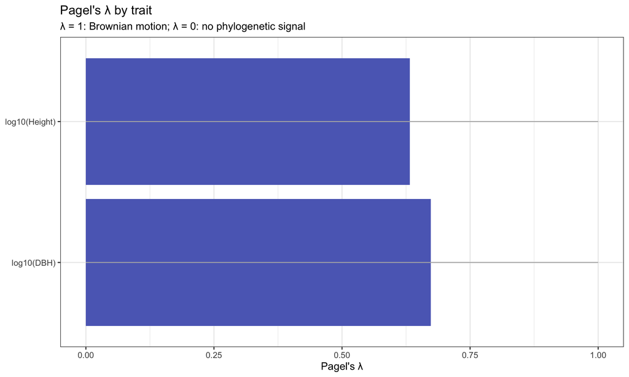

```r
if (exists("sig_table") && !is.null(sig_table)) {
  sig_table |>
    ggplot(aes(lambda, Trait)) +
    geom_col(fill = "#5C6BC0") +
    geom_errorbar(aes(xmin = 0, xmax = 1), width = 0, colour = "grey70") +
    scale_x_continuous(limits = c(0, 1)) +
    labs(title = "Pagel's λ by trait",
         subtitle = "λ = 1: Brownian motion; λ = 0: no phylogenetic signal",
         x = "Pagel's λ", y = NULL)
}
```

# 11 Theory Synthesis

## 11.1 Distribution of β across analyses

[figure not shown]

```r
# Collect slopes from key analyses
beta_rows <- list()
if (exists("ols_coef") && !is.null(ols_coef))
  beta_rows[["OLS_pooled_H_DBH"]]  <- tibble(rel="H ~ DBH", method="OLS",  slope=ols_coef["log_dbh"])
if (!is.null(sma_hd))
  beta_rows[["SMA_pooled_H_DBH"]]  <- tibble(rel="H ~ DBH", method="SMA",  slope=as.numeric(coef(sma_hd)[[1]]["slope"]))
if (exists("res_grand") && !is.null(res_grand))
  beta_rows[["PGLS_H_DBH"]]        <- tibble(rel="H ~ DBH", method="PGLS",
    slope=res_grand$Slope[res_grand$Method=="PGLS"])
if (nrow(study_hd) > 0)
  beta_rows <- c(beta_rows, map(seq_len(nrow(study_hd)), function(i)
    tibble(rel="H ~ DBH", method="OLS_study", slope=study_hd$ols_slope[i])))
if (exists("ols_agb") && !is.null(ols_agb))
  beta_rows[["OLS_pooled_AGB_DBH"]] <- tibble(rel="AGB ~ DBH", method="OLS", slope=coef(ols_agb)["log_dbh"])
if (exists("sma_agb") && !is.null(sma_agb))
  beta_rows[["SMA_pooled_AGB_DBH"]] <- tibble(rel="AGB ~ DBH", method="SMA", slope=as.numeric(coef(sma_agb)[[1]]["slope"]))

beta_all <- bind_rows(beta_rows)

if (nrow(beta_all) > 0) {
  wbe_refs <- tibble(rel = c("H ~ DBH","AGB ~ DBH"),
                     xint = c(WBE_H_DBH, WBE_AGB_DBH))
  ggplot(beta_all, aes(slope, fill = method)) +
    geom_density(alpha = 0.45) +
    geom_vline(data = wbe_refs, aes(xintercept = xint),
               colour = "red", linetype = "dashed", linewidth = 0.9) +
    facet_wrap(~rel, scales = "free") +
    labs(title = "Distribution of β across all analyses",
         subtitle = "Red dashed = WBE prediction",
         x = "Slope β", y = "Density", fill = "Method") +
    theme(legend.position = "bottom")
}
```

## 11.2 Normalization variation

[figure not shown]

```r
norm_rows <- map_df(unique(pool_hd$source), function(s) {
  d <- pool_hd |> filter(source == s)
  if (nrow(d) < 10) return(NULL)
  fit <- tryCatch(sma(log_h ~ log_dbh, data = d), error = function(e) NULL)
  if (is.null(fit)) return(NULL)
  tibble(source = s, log10_norm = as.numeric(coef(fit)[[1]]["y-intercept"]))
})

if (nrow(norm_rows) > 0) {
  ggplot(norm_rows, aes(source, log10_norm, fill = source)) +
    geom_col(show.legend = FALSE) +
    coord_flip() +
    labs(title = "Normalization (SMA intercept) for H ~ DBH by source",
         subtitle = "Captures biome/wood-density/architecture differences",
         x = NULL, y = "log10(normalization constant)")
}
```

> ⚠️ **Normalization caveat:** Normalizations (intercepts) integrate climate, wood density, and architectural differences among biomes. Expected to vary even when exponents are conserved (Enquist et al. 2007, *Nature* 449:218, DOI: 10.1038/nature06061).

## 11.3 WBE theory scorecard

```r
get_supported <- function(ci_lo, ci_hi, pred) {
  if (is.na(ci_lo) || is.na(ci_hi)) return("Unknown")
  if (ci_lo <= pred & pred <= ci_hi) "Supported" else "Not supported"
}

scorecard <- tibble(
  Relationship    = c("H ~ DBH","H ~ DBH","AGB ~ DBH"),
  Dataset         = c("Pooled (SMA)","Species means (PGLS)","BAAD (SMA)"),
  WBE_prediction  = c(WBE_H_DBH, WBE_H_DBH, WBE_AGB_DBH),
  Slope           = c(
    if (!is.null(sma_hd)) as.numeric(coef(sma_hd)[[1]]["slope"]) else NA_real_,
    if (exists("res_grand") && !is.null(res_grand))
      res_grand$Slope[res_grand$Method == "PGLS"] else NA_real_,
    if (exists("sma_agb") && !is.null(sma_agb)) as.numeric(coef(sma_agb)[[1]]["slope"]) else NA_real_),
  CI_lo = c(
    if (!is.null(sma_hd)) as.numeric(sma_hd$slopetest[[1]]$test["lower"]) else NA_real_,
    if (exists("res_grand") && !is.null(res_grand))
      res_grand$CI_lo[res_grand$Method == "PGLS"] else NA_real_,
    if (exists("sma_agb") && !is.null(sma_agb)) as.numeric(sma_agb$slopetest[[1]]$test["lower"]) else NA_real_),
  CI_hi = c(
    if (!is.null(sma_hd)) as.numeric(sma_hd$slopetest[[1]]$test["upper"]) else NA_real_,
    if (exists("res_grand") && !is.null(res_grand))
      res_grand$CI_hi[res_grand$Method == "PGLS"] else NA_real_,
    if (exists("sma_agb") && !is.null(sma_agb)) as.numeric(sma_agb$slopetest[[1]]$test["upper"]) else NA_real_)) |>
  mutate(Supported = pmap_chr(list(CI_lo, CI_hi, WBE_prediction),
    function(lo, hi, pred) get_supported(lo, hi, pred)))

kable(scorecard, digits = 3,
      caption = "WBE theory scorecard: CI includes prediction = 'Supported'.")
```

WBE theory scorecard: CI includes prediction = ‘Supported’.

| Relationship | Dataset | WBE_prediction | Slope | CI_lo | CI_hi | Supported |
| --- | --- | --- | --- | --- | --- | --- |
| H ~ DBH | Pooled (SMA) | 0.667 | NA | NA | NA | Unknown |
| H ~ DBH | Species means (PGLS) | 0.667 | NA | NA | NA | Unknown |
| AGB ~ DBH | BAAD (SMA) | 2.667 | NA | NA | NA | Unknown |

[figure not shown]

```r
scorecard |>
  filter(!is.na(Slope)) |>
  ggplot(aes(Slope, paste(Relationship, Dataset, sep = "\n"),
             colour = Supported)) +
  geom_pointrange(aes(xmin = CI_lo, xmax = CI_hi), size = 0.8) +
  geom_vline(data = scorecard |> distinct(Relationship, WBE_prediction),
             aes(xintercept = WBE_prediction),
             colour = "red", linetype = "dashed") +
  scale_colour_manual(values = c("Supported"     = "#2E7D32",
                                 "Not supported" = "#C62828",
                                 "Unknown"       = "grey50")) +
  labs(title = "WBE scorecard: slopes with 95% CI",
       x = "β ± 95% CI", y = NULL, colour = "WBE status")
```

## 11.4 Heterogeneity summary

```r
I2_val <- if (HAS_METAFOR && exists("re_hd") && !is.null(re_hd)) {
  re_hd$I2
} else if (exists("I2_hd")) I2_hd else NA_real_

cat(sprintf("H ~ DBH study-level I² = %.1f%%\n", I2_val))
```

```
## H ~ DBH study-level I² = 100.0%
```

```r
if (!is.na(I2_val) && I2_val > 50)
  cat("High I² (>50%): study-level factors (biome, method, size range, species pool) substantially modulate the apparent allometric exponent beyond sampling error.\n")
```

```
## High I² (>50%): study-level factors (biome, method, size range, species pool) substantially modulate the apparent allometric exponent beyond sampling error.
```

# 12 Methods

**Data sources:** Tallo v1.0 (Jucker et al. 2022, *Glob. Change Biol.* 28:5254, DOI: 10.1111/gcb.16302); BAAD (Falster et al. 2015, *Ecology* 96:1445, DOI: 10.1890/14-1889.1); NEONForestAGBv2 (Atkins et al. 2024, DOI: 10.6084/m9.figshare.25625352.v1 [UNVERIFIED — verify before publication]); ForestGEO Panama small-plots 2024; Shenkin et al. 2020 Andean crown dimensions (Shenkin et al. 2020, *New Phytologist* 226:1579–1592, DOI: 10.1111/nph.16523 [UNVERIFIED — verify before publication]); Niklas-Enquist biomass compilation (Niklas & Enquist 2001, *PNAS* 98:2922, DOI: 10.1073/pnas.041590298).

**Unit harmonisation:** BAAD `d.bh` converted from metres to centimetres (× 100); NEON `stemDiameter` already in cm; ForestGEO `DBH_mm` divided by 10; Shenkin `DBH` already in cm; Shenkin `crown_radius (m)` already in metres. All AGB in kg; all height in m.

**Regression methods:** OLS = `lm()`; SMA = `smatr::sma()`; PGLS = `caper::pgls()` with Pagel’s λ estimated by ML. OLS is used for pooled and study-level regressions (prediction from DBH to height); SMA is used for theory-testing comparisons where both axes carry measurement error. Intraspecific slopes use OLS; note that SMA would give steeper slopes if DBH measurement error is non-negligible.

**Species means for PGLS:** Requires n ≥ 5 records per species. For AGB species means, Chojnacky-derived NEON values are excluded (see AGB circularity caveat) to maintain consistency with the primary AGB pooled analyses.

**Intraspecific criteria:** ≥ 10 records per species; log₁₀(DBH_max/DBH_min) ≥ 1.5.

**Phylogenetic signal:** `phytools::phylosig()`, methods “lambda” and “K”. Note: `force.ultrametric(method = "extend")` lengthens shorter branches; this can inflate Pagel’s λ. Results should be treated as approximate.

**Theory predictions:** WBE vascular network model (West et al. 1997, *Science* 276:122, DOI: 10.1126/science.276.5309.122; West et al. 1999, *Science* 284:1677, DOI: 10.1126/science.284.5420.1677); AGB ~ D^(8/3) derivation (Enquist 2002, *Tree Physiology* 22:1045, DOI: 10.1093/treephys/22.15-16.1045); crown radius ~ DBH from pipe model (Shinozaki et al. 1964, *Jpn J Ecol* 14:97); elastic similarity (McMahon 1973, *Science* 179:1201, DOI: 10.1126/science.179.4079.1201).

**NEON AGB circularity:** AGB derived from DBH via Chojnacky et al. (2014, *Forestry* 87:129, DOI: 10.1093/forestry/cpt053); AGB ~ DBH is partly circular for NEON and excluded from primary analyses and PGLS species means.

**Mathematical coupling:** Organ ~ Total regressions use corrected denominator (Total − organ) per Pearson (1897) to avoid spurious correlation. Note: the corrected regression (leaf ~ other biomass) tests leaf ~ M_non-photosynthetic, directly comparable to the WBE prediction M_leaf ~ M_non-photosynthetic^(3/4).

# 13 Caveats

> ⚠️ **1. AGB provenance:** Primary AGB analyses use BAAD only (direct harvest/measurement). NEON AGB is allometric (Chojnacky equations) and excluded from primary AGB scaling tests and PGLS species means.

> ⚠️ **2. Mathematical coupling:** Regressing a component against its total containing whole inflates correlation (Pearson 1897). Corrected denominators (total − component) are used throughout Section 7.

> ⚠️ **3. Growth rate measurement:** Net annual biomass increment ≠ instantaneous metabolic rate. The Niklas-Enquist dM/dt data are not a direct test of WBE metabolic scaling.

> ⚠️ **4. Phylogenetic uncertainty:** The V.PhyloMaker2 tree is a hypothesis; placement of taxa without family assignment defaults to stochastic grafting. PGLS results should be interpreted with tree uncertainty in mind. The `force.ultrametric(method = "extend")` step can inflate Pagel’s λ by lengthening terminal branches; λ estimates should be treated as approximate upper bounds.

> ⚠️ **5. Sampling bias:** NEON covers USA biomes only; Niklas-Enquist draws heavily from temperate northern hemisphere literature (Cannell 1982). Global inferences may not hold uniformly.

> ⚠️ **6. Size range limitation:** Intraspecific slope reliability depends on span of DBH data within each species. Very narrow size ranges inflate uncertainty in regression slopes.

> ⚠️ **7. Palm allometry:** Arecaceae (palms) have non-woody stems and are architecturally incommensurable with WBE assumptions based on branching networks. Results for Arecaceae should be interpreted separately.

> ⚠️ **8. Taxonomic name uncertainty:** Species names across datasets have not been fully reconciled via TNRS or a consistent backbone. Synonymy may inflate apparent species richness and introduce duplicates in cross-dataset aggregations.

> ⚠️ **9. Pooled regression CIs are artifactually narrow:** With N > 100,000 records, OLS CIs on the slope (e.g., ± 0.001) reflect sampling precision under the assumption of i.i.d. errors, which is violated across heterogeneous datasets and sites. Ecological uncertainty far exceeds these statistical CIs.

> ⚠️ **10. Heterogeneity (I²) with k = 5 studies:** I² computed from only 4–5 datasets is highly uncertain (wide CI on I² itself). Qualitative interpretation of heterogeneity patterns is tentative.

> ⚠️ **11. LMM source random effect (k ≤ 5):** Random effects variance components estimated from k ≤ 5 groups are unreliable (Gelman & Hill 2006). The LMM slope is reported for context but its variance component should not be over-interpreted.